# Construction of a Policy Decision-Analytic Model Using Global Burden of Disease Data

Structuring and Adapting Models for Multidimensional Health Outcomes

CEA

Author

John Graves

Published

December 15, 2023

**Setup R session**

```r
library(tidyverse)
library(here)
library(glue)
library(demography)
library(MortalityLaws)
library(janitor)
library(data.table)
library(expm)
transpose <- purrr::transpose
library(dtplyr)
library(ggsci)
library(directlabels)
library(knitr)
library(kableExtra)
library(hrbrthemes)
library(furrr)
library(tictoc)
library(patchwork)


rate_to_prob <- function(x) 1-exp(-x)
prob_to_rate <- function(x) -log(1-x)

options(scipen = 5)
select <- dplyr::select
options(knitr.kable.NA = '')

gen_wcc <- function (n_cycles, method = c("Simpson1/3", "half-cycle", "none"))
{
    if (n_cycles <= 0) {
        stop("Number of cycles should be positive")
    }
    method <- match.arg(method)
    n_cycles <- as.integer(n_cycles)
    if (method == "Simpson1/3") {
        v_cycles <- seq(1, n_cycles + 1)
        v_wcc <- ((v_cycles%%2) == 0) * (2/3) + ((v_cycles%%2) !=
                                                     0) * (4/3)
        v_wcc[1] <- v_wcc[n_cycles + 1] <- 1/3
    }
    if (method == "half-cycle") {
        v_wcc <- rep(1, n_cycles + 1)
        v_wcc[1] <- v_wcc[n_cycles + 1] <- 0.5
    }
    if (method == "none") {
        v_wcc <- rep(1, n_cycles + 1)
    }
    return(v_wcc)
}

age_group_lut <- c(
    "5" = 1,
    "6" = 5,
    "7" = 10,
    "8" = 15,
    "9" = 20,
    "10" = 25,
    "11" = 30,
    "12" = 35,
    "13" = 40,
    "14" = 45,
    "15" = 50,
    "16" = 55,
    "17" = 60,
    "18" = 65,
    "19" = 70,
    "20" = 75,
    "30" = 80,
    "31" = 85,
    "32" = 90,
    "33" = 95,
    "44" = 100,
    "45" = 105,
    "148" = 110,
    "28" = 0
)

lut_age_incidence =
tibble::tribble(
  ~age_name, ~age,
  "<1 year",  0L,
  "1-4 years",  1L,
  "5-9 years",  5L,
  "10-14 years", 10L,
  "15-19 years", 15L,
  "20-24 years", 20L,
  "25-29 years", 25L,
  "30-34 years", 30L,
  "35-39 years", 35L,
  "40-44 years", 40L,
  "45-49 years", 45L,
  "50-54 years", 50L,
  "55-59 years", 55L,
  "60-64 years", 60L,
  "65-69 years", 65L,
  "70-74 years", 70L,
  "75-79 years", 75L,
  "80-84", 80L,
  "85-89", 85L,
  "90-94", 90L,
  "95+ years", 95L
)
```

# Introduction

Our objective is to construct a decision model using data and parameters from the [2019 Global Burden of Disease study](https://www.healthdata.org/research-analysis/gbd).

We will consider three methods:

1. A **Markov Trace-Based** approach that separately tracks deaths from disease and from other non-disease-related causes, and uses differences in disease-related deaths across cycles to calculate years of life lost to disease (YLLs).
2. A **Transition States** approach that is similar to Markov trace approach, but that draws on a death tracking state to calculate YLLs.
3. A **Markov Chain with Rewards** approach to Healthy Longevity as developed in Caswell and Zarulli (2018) and Caswell and Daalen (2021).

Our model will be flexibly parameterized such that practitioners can model any disease or country/region represented in the GBD data. For our purposes here, however, we will focus on a general cardiovascular disease model for the United Kingdom, and using country mortality data for 2019. We will also focus on a pooled model for the full population—though the GBD data do allow us to separately model mortality and disease-specific incidence and death separately for males and females.

A state (“bubble”) diagram of our basic model structure is provided below:

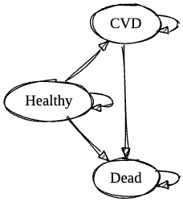

State Diagram for Cardiovascular Disease Model

```r
life_table_year = 2019
location = "United Kingdom"
cause_id = 491 # CVD
sex = "Both"
radix = 100000
```

# Data Sources

Data Sources and Citatations

| Description | Source |
| --- | --- |
| [Life Tables](https://ghdx.healthdata.org/record/ihme-data/gbd-2019-life-tables-1950-2019) | Global Burden of Disease Collaborative Network (2020a) |
| [Disease Incidence](https://vizhub.healthdata.org/gbd-results/) | Global Burden of Disease Collaborative Network (2020b) |
| [Disease-Related Death](https://vizhub.healthdata.org/gbd-results/) | Global Burden of Disease Collaborative Network (2020b) |
| [Disease Prevalence by Age](https://vizhub.healthdata.org/gbd-results/) | Global Burden of Disease Collaborative Network (2020b) |
| [Reference Life Table](https://ghdx.healthdata.org/record/ihme-data/global-burden-disease-study-2019-gbd-2019-reference-life-table) | Global Burden of Disease Collaborative Network (2021) |

# Population Data

```r
if (!file.exists(here(glue("blog/posts/dalys-around-the-world/_data/gbd_population_{location}-{life_table_year}.rds")))) {
  gbd_population <- c("https://ghdx.healthdata.org/sites/default/files/record-attached-files/IHME_GBD_2019_POP_2010_2019_SYA.zip")

  population <-
      gbd_population %>% map(~ ({
        cat(glue::glue("File: {.x}\n"))
        tmp <- tempfile()
        tmpdir <- tempdir()
        download.file(.x, tmp)
        nn <-
          gsub(
            "https://ghdx.healthdata.org/sites/default/files/record-attached-files/",
            "",
            .x
          ) %>% gsub(".ZIP|.zip", "", .)
        unzip(tmp)
        ff <- list.files(here(), pattern = ".CSV|.csv")
        df_pop <-
          ff[grep(glue("SYA_{life_table_year}"),ff)] %>%
          map(~(read.csv(.x) %>% as_tibble() %>% mutate(file = .x))) %>% pluck(1) %>%
          filter(location_name == location & sex_name == tolower(sex))
        file.remove(ff)
        df_pop
      })) %>%
      bind_rows()

  df_population <-
    population  %>%
    select(age_group_name,val) %>%
    mutate(age_group_name = ifelse(age_group_name=="<1 year","0",age_group_name))  %>%
    mutate(age_group_name = ifelse(age_group_name=="95 plus","95",age_group_name))  %>%
    mutate(age_name = as.numeric(paste0(age_group_name))) %>%
    mutate(age_name = cut(age_name,labels = lut_age_incidence$age_name, right = FALSE,breaks = c(0,1,seq(5,95,5),110))) %>%
    group_by(age_name) %>%
    summarise(population=sum(val)) %>%
    left_join(lut_age_incidence,"age_name")


  df_population %>% write_rds(here(glue("blog/posts/dalys-around-the-world/_data/gbd_population_{location}-{life_table_year}.rds")))
}

df_population <- read_rds(here(glue("blog/posts/dalys-around-the-world/_data/gbd_population_{location}-{life_table_year}.rds")))
```

# Cause-Deleted Life Tables

## Life Tables

The GBD life table data are arranged by age group, so we need to download a separate file for each group, and extract the relevant location and year.

**Download and process GBD life table data.**

```r
if (!file.exists(here(glue("blog/posts/dalys-around-the-world/_data/gbd_life_table_{location}-{life_table_year}.rds")))) {
    gbd_life_tables <- c(
      "https://ghdx.healthdata.org/sites/default/files/record-attached-files/IHME_GBD_2019_LIFE_TABLES_1950_2019_ID_28_0.zip",
      "https://ghdx.healthdata.org/sites/default/files/record-attached-files/IHME_GBD_2019_LIFE_TABLES_1950_2019_ID_5_0.zip",
      "https://ghdx.healthdata.org/sites/default/files/record-attached-files/IHME_GBD_2019_LIFE_TABLES_1950_2019_ID_6_0.zip",
      "https://ghdx.healthdata.org/sites/default/files/record-attached-files/IHME_GBD_2019_LIFE_TABLES_1950_2019_ID_7_0.zip",
      "https://ghdx.healthdata.org/sites/default/files/record-attached-files/IHME_GBD_2019_LIFE_TABLES_1950_2019_ID_8_0.zip",
      "https://ghdx.healthdata.org/sites/default/files/record-attached-files/IHME_GBD_2019_LIFE_TABLES_1950_2019_ID_9_0.zip",
      "https://ghdx.healthdata.org/sites/default/files/record-attached-files/IHME_GBD_2019_LIFE_TABLES_1950_2019_ID_10_0.zip",
      "https://ghdx.healthdata.org/sites/default/files/record-attached-files/IHME_GBD_2019_LIFE_TABLES_1950_2019_ID_11_0.zip",
      "https://ghdx.healthdata.org/sites/default/files/record-attached-files/IHME_GBD_2019_LIFE_TABLES_1950_2019_ID_12_0.zip",
      "https://ghdx.healthdata.org/sites/default/files/record-attached-files/IHME_GBD_2019_LIFE_TABLES_1950_2019_ID_13_0.zip",
      "https://ghdx.healthdata.org/sites/default/files/record-attached-files/IHME_GBD_2019_LIFE_TABLES_1950_2019_ID_14_0.zip",
      "https://ghdx.healthdata.org/sites/default/files/record-attached-files/IHME_GBD_2019_LIFE_TABLES_1950_2019_ID_15_0.zip",
      "https://ghdx.healthdata.org/sites/default/files/record-attached-files/IHME_GBD_2019_LIFE_TABLES_1950_2019_ID_16_0.zip",
      "https://ghdx.healthdata.org/sites/default/files/record-attached-files/IHME_GBD_2019_LIFE_TABLES_1950_2019_ID_17_0.zip",
      "https://ghdx.healthdata.org/sites/default/files/record-attached-files/IHME_GBD_2019_LIFE_TABLES_1950_2019_ID_18_0.zip",
      "https://ghdx.healthdata.org/sites/default/files/record-attached-files/IHME_GBD_2019_LIFE_TABLES_1950_2019_ID_19_0.zip",
      "https://ghdx.healthdata.org/sites/default/files/record-attached-files/IHME_GBD_2019_LIFE_TABLES_1950_2019_ID_20_0.zip",
      "https://ghdx.healthdata.org/sites/default/files/record-attached-files/IHME_GBD_2019_LIFE_TABLES_1950_2019_ID_30_0.zip",
      "https://ghdx.healthdata.org/sites/default/files/record-attached-files/IHME_GBD_2019_LIFE_TABLES_1950_2019_ID_31_0.zip",
      "https://ghdx.healthdata.org/sites/default/files/record-attached-files/IHME_GBD_2019_LIFE_TABLES_1950_2019_ID_32_0.zip",
      "https://ghdx.healthdata.org/sites/default/files/record-attached-files/IHME_GBD_2019_LIFE_TABLES_1950_2019_ID_33_0.zip",
      "https://ghdx.healthdata.org/sites/default/files/record-attached-files/IHME_GBD_2019_LIFE_TABLES_1950_2019_ID_44_0.zip",
      "https://ghdx.healthdata.org/sites/default/files/record-attached-files/IHME_GBD_2019_LIFE_TABLES_1950_2019_ID_45_0.zip",
      "https://ghdx.healthdata.org/sites/default/files/record-attached-files/IHME_GBD_2019_LIFE_TABLES_1950_2019_ID_148_0.zip"
  )

  life_table <-
    gbd_life_tables %>% map(~ ({
      cat(glue::glue("File: {.x}\n"))
      tmp <- tempfile()
      tmpdir <- tempdir()
      download.file(.x, tmp)
      nn <-
        gsub(
          "https://ghdx.healthdata.org/sites/default/files/record-attached-files/",
          "",
          .x
        ) %>% gsub(".ZIP|.zip", "", .)
      unzip(tmp)
      ff <- list.files(here(), pattern = ".CSV|.csv")
      lt_age_group <-
        ff[grep("WSHOCK", ff)] %>% map( ~ (read.csv(.x) %>% as_tibble() %>% mutate(file = .x))) %>% pluck(1) %>%
        filter(year_id == life_table_year &
                 location_name == location)

      file.remove(ff)
      lt_age_group
    })) %>%
    bind_rows()

  lt <-
    life_table %>%
    group_by(location_name, location_id) %>%
    nest()  %>%
    mutate(life_table = map(data,  ~ ({
      .x %>% select(sex_name, age_group_id, age_group_name, measure_name, val) %>%
        mutate(age = age_group_lut[paste0(age_group_id)]) %>%
        spread(measure_name, val) %>%
        janitor::clean_names() %>%
        rename(ex = life_expectancy,
               qx = probability_of_death) %>%
        arrange(sex_name, age) %>%
        select(sex_name, age, ex, qx) %>%
        gather(measure, value, -sex_name, -age) %>%
        mutate(measure = paste0(measure, gsub("_both", "", paste0("_", sex_name)))) %>%
        select(-sex_name)  %>%
        spread(measure, value) %>%
        mutate(
          p = 1 - qx,
          p_male = 1 - qx_male,
          p_female = 1 - qx_female
        ) %>%
        mutate(
          lx = radix * cumprod(c(1, p[-nrow(.)])),
          lx_male = radix * cumprod(c(1, p_male[-nrow(.)])),
          lx_female = radix * cumprod(c(1, p_female[-nrow(.)]))
        )
    })))

  lt <-
    lt %>%
    mutate(hp_mort = map(life_table,  ~ ({
      ages     <- .x$age
      deaths   <- .x$lx * .x$qx
      exposure <- .x$lx

      mort_fit <- MortalityLaw(
        x  = ages,
        Dx  = deaths,
        # vector with death counts
        Ex  = exposure,
        # vector containing exposures
        law = "HP2",
        opt.method = "LF2"
      )
      coef(mort_fit) %>% data.frame() %>% t()
    })))

  lt %>% write_rds(here(glue("blog/posts/dalys-around-the-world/_data/gbd_life_table_{location}-{life_table_year}.rds")))

}
df_life_table = read_rds(here(glue("blog/posts/dalys-around-the-world/_data/gbd_life_table_{location}-{life_table_year}.rds")))
```

### Life Tables

```r
lt <-
    df_life_table %>%
    select(location_name,location_id,life_table) %>%
    unnest(cols = c(life_table))  %>%
    select(location_name, location_id, age, ex, qx)   %>%
    mutate(age_diff = c(1,lead(diff(age)))) %>%   # Age difference in age group
    mutate(mx = -log(1 - qx)/age_diff) %>%  # Mortality rate
    select(location_name, location_id, age, ex, qx, mx)  %>%
    mutate(p = 1 - qx) %>%  # Survival probability
    mutate(cump = ifelse(row_number() == 1, 1, lag(cumprod(p)))) %>% # Cumulative survival
    mutate(lx = radix * cump) %>% # At risk
    mutate(dx = lx * qx) %>% # Deaths = at risk * probability of death
    as.data.table()
setkey(lt, age)
```

## GBD Incidence and Cause of Death Data

We’ll use the [GBD data tool](https://vizhub.healthdata.org/gbd-results/). Note you need a login to download.

[figure not shown]

(a) Cause of Death

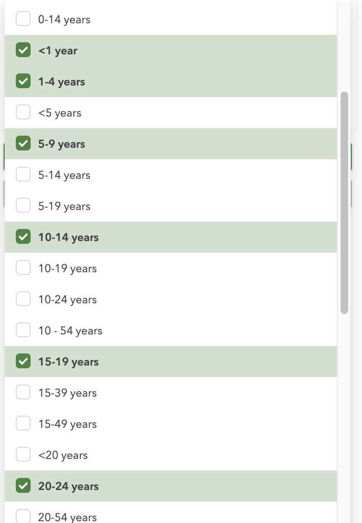

(b) Age Ranges

Figure 1: Global Burden of Disease Data Query Tool

You can then click on “Download.” To obtain the data in the code below, I downloaded the .csv file and used the datapasta package in R to simply copy and paste the values as a table. Alternatively, you could just manually load the .csv file.

**Download and process GBD CVD incidence and cause of death data.**

```r
df_gbd <-
tibble::tribble(
    ~measure_id, ~measure_name, ~location_id,   ~location_name, ~sex_id, ~sex_name, ~age_id,     ~age_name, ~cause_id,               ~cause_name, ~metric_id, ~metric_name, ~year,        ~val,      ~upper,      ~lower,
             1L,      "Deaths",          95L, "United Kingdom",      1L,    "Male",      5L,   "1-4 years",      491L, "Cardiovascular diseases",         2L,    "Percent", 2019L, 0.028996032, 0.032271777, 0.024354871,
             1L,      "Deaths",          95L, "United Kingdom",      2L,  "Female",      5L,   "1-4 years",      491L, "Cardiovascular diseases",         2L,    "Percent", 2019L, 0.035378341, 0.038200527,  0.02982068,
             1L,      "Deaths",          95L, "United Kingdom",      3L,    "Both",      5L,   "1-4 years",      491L, "Cardiovascular diseases",         2L,    "Percent", 2019L, 0.031923654, 0.033877513,  0.02749347,
             1L,      "Deaths",          95L, "United Kingdom",      1L,    "Male",      5L,   "1-4 years",      491L, "Cardiovascular diseases",         3L,       "Rate", 2019L, 0.450558018, 0.518217768, 0.366558761,
             1L,      "Deaths",          95L, "United Kingdom",      2L,  "Female",      5L,   "1-4 years",      491L, "Cardiovascular diseases",         3L,       "Rate", 2019L, 0.489648455, 0.546394959, 0.415998276,
             1L,      "Deaths",          95L, "United Kingdom",      3L,    "Both",      5L,   "1-4 years",      491L, "Cardiovascular diseases",         3L,       "Rate", 2019L, 0.469612322, 0.520633016, 0.400518019,
             1L,      "Deaths",          95L, "United Kingdom",      1L,    "Male",      6L,   "5-9 years",      491L, "Cardiovascular diseases",         2L,    "Percent", 2019L, 0.028030375, 0.030218263, 0.025065873,
             1L,      "Deaths",          95L, "United Kingdom",      2L,  "Female",      6L,   "5-9 years",      491L, "Cardiovascular diseases",         2L,    "Percent", 2019L, 0.034179575, 0.038337972, 0.030031173,
             1L,      "Deaths",          95L, "United Kingdom",      3L,    "Both",      6L,   "5-9 years",      491L, "Cardiovascular diseases",         2L,    "Percent", 2019L, 0.030684194, 0.032765225, 0.027736481,
             1L,      "Deaths",          95L, "United Kingdom",      1L,    "Male",      6L,   "5-9 years",      491L, "Cardiovascular diseases",         3L,       "Rate", 2019L, 0.223162961, 0.243068851, 0.195925728,
             1L,      "Deaths",          95L, "United Kingdom",      2L,  "Female",      6L,   "5-9 years",      491L, "Cardiovascular diseases",         3L,       "Rate", 2019L, 0.216691535, 0.243515145,  0.18996081,
             1L,      "Deaths",          95L, "United Kingdom",      3L,    "Both",      6L,   "5-9 years",      491L, "Cardiovascular diseases",         3L,       "Rate", 2019L, 0.220004378, 0.236329232, 0.198461094,
             1L,      "Deaths",          95L, "United Kingdom",      1L,    "Male",      7L, "10-14 years",      491L, "Cardiovascular diseases",         2L,    "Percent", 2019L, 0.039746344, 0.041717485, 0.036621253,
             1L,      "Deaths",          95L, "United Kingdom",      2L,  "Female",      7L, "10-14 years",      491L, "Cardiovascular diseases",         2L,    "Percent", 2019L, 0.039007566, 0.043057948, 0.035699452,
             1L,      "Deaths",          95L, "United Kingdom",      3L,    "Both",      7L, "10-14 years",      491L, "Cardiovascular diseases",         2L,    "Percent", 2019L,  0.03942622, 0.041491836, 0.036825279,
             1L,      "Deaths",          95L, "United Kingdom",      1L,    "Male",      7L, "10-14 years",      491L, "Cardiovascular diseases",         3L,       "Rate", 2019L, 0.383598812, 0.405724933,  0.34991092,
             1L,      "Deaths",          95L, "United Kingdom",      2L,  "Female",      7L, "10-14 years",      491L, "Cardiovascular diseases",         3L,       "Rate", 2019L, 0.301487698, 0.333401339, 0.275739379,
             1L,      "Deaths",          95L, "United Kingdom",      3L,    "Both",      7L, "10-14 years",      491L, "Cardiovascular diseases",         3L,       "Rate", 2019L, 0.343507011,  0.36308575, 0.319699847,
             1L,      "Deaths",          95L, "United Kingdom",      1L,    "Male",      8L, "15-19 years",      491L, "Cardiovascular diseases",         2L,    "Percent", 2019L, 0.040429815, 0.042516915, 0.038634534,
             1L,      "Deaths",          95L, "United Kingdom",      2L,  "Female",      8L, "15-19 years",      491L, "Cardiovascular diseases",         2L,    "Percent", 2019L, 0.050448817, 0.056212097, 0.047257679,
             1L,      "Deaths",          95L, "United Kingdom",      3L,    "Both",      8L, "15-19 years",      491L, "Cardiovascular diseases",         2L,    "Percent", 2019L, 0.043765321, 0.046440911, 0.041928954,
             1L,      "Deaths",          95L, "United Kingdom",      1L,    "Male",      8L, "15-19 years",      491L, "Cardiovascular diseases",         3L,       "Rate", 2019L, 1.272151624, 1.340633778, 1.215478459,
             1L,      "Deaths",          95L, "United Kingdom",      2L,  "Female",      8L, "15-19 years",      491L, "Cardiovascular diseases",         3L,       "Rate", 2019L, 0.830116477, 0.926181301, 0.778133659,
             1L,      "Deaths",          95L, "United Kingdom",      3L,    "Both",      8L, "15-19 years",      491L, "Cardiovascular diseases",         3L,       "Rate", 2019L, 1.056297216, 1.122235147, 1.011670449,
             1L,      "Deaths",          95L, "United Kingdom",      1L,    "Male",      9L, "20-24 years",      491L, "Cardiovascular diseases",         2L,    "Percent", 2019L, 0.047865254, 0.049912826, 0.045757303,
             1L,      "Deaths",          95L, "United Kingdom",      2L,  "Female",      9L, "20-24 years",      491L, "Cardiovascular diseases",         2L,    "Percent", 2019L, 0.064022359, 0.070540903, 0.060728528,
             1L,      "Deaths",          95L, "United Kingdom",      3L,    "Both",      9L, "20-24 years",      491L, "Cardiovascular diseases",         2L,    "Percent", 2019L,  0.05241896, 0.055214123, 0.050297559,
             1L,      "Deaths",          95L, "United Kingdom",      1L,    "Male",      9L, "20-24 years",      491L, "Cardiovascular diseases",         3L,       "Rate", 2019L, 2.584733912, 2.705960617, 2.466297393,
             1L,      "Deaths",          95L, "United Kingdom",      2L,  "Female",      9L, "20-24 years",      491L, "Cardiovascular diseases",         3L,       "Rate", 2019L, 1.396334943, 1.540852926, 1.320505171,
             1L,      "Deaths",          95L, "United Kingdom",      3L,    "Both",      9L, "20-24 years",      491L, "Cardiovascular diseases",         3L,       "Rate", 2019L, 1.999067921, 2.108246777, 1.910639006,
             1L,      "Deaths",          95L, "United Kingdom",      1L,    "Male",     10L, "25-29 years",      491L, "Cardiovascular diseases",         2L,    "Percent", 2019L, 0.089939927,  0.09346508, 0.086949806,
             1L,      "Deaths",          95L, "United Kingdom",      2L,  "Female",     10L, "25-29 years",      491L, "Cardiovascular diseases",         2L,    "Percent", 2019L, 0.089152972, 0.094352463,  0.08473271,
             1L,      "Deaths",          95L, "United Kingdom",      3L,    "Both",     10L, "25-29 years",      491L, "Cardiovascular diseases",         2L,    "Percent", 2019L, 0.089703584, 0.092727269, 0.086724818,
             1L,      "Deaths",          95L, "United Kingdom",      1L,    "Male",     10L, "25-29 years",      491L, "Cardiovascular diseases",         3L,       "Rate", 2019L, 5.734533296, 5.967850508, 5.529144225,
             1L,      "Deaths",          95L, "United Kingdom",      2L,  "Female",     10L, "25-29 years",      491L, "Cardiovascular diseases",         3L,       "Rate", 2019L, 2.476079844, 2.623849325, 2.341002774,
             1L,      "Deaths",          95L, "United Kingdom",      3L,    "Both",     10L, "25-29 years",      491L, "Cardiovascular diseases",         3L,       "Rate", 2019L, 4.117495802, 4.260669343, 3.978963164,
             1L,      "Deaths",          95L, "United Kingdom",      1L,    "Male",     11L, "30-34 years",      491L, "Cardiovascular diseases",         2L,    "Percent", 2019L, 0.127257147,  0.13212298, 0.122966034,
             1L,      "Deaths",          95L, "United Kingdom",      2L,  "Female",     11L, "30-34 years",      491L, "Cardiovascular diseases",         2L,    "Percent", 2019L, 0.101388841, 0.105278948, 0.097807228,
             1L,      "Deaths",          95L, "United Kingdom",      3L,    "Both",     11L, "30-34 years",      491L, "Cardiovascular diseases",         2L,    "Percent", 2019L, 0.118479515, 0.122297221, 0.114897896,
             1L,      "Deaths",          95L, "United Kingdom",      1L,    "Male",     11L, "30-34 years",      491L, "Cardiovascular diseases",         3L,       "Rate", 2019L, 10.53187361, 10.94789275, 10.15541571,
             1L,      "Deaths",          95L, "United Kingdom",      2L,  "Female",     11L, "30-34 years",      491L, "Cardiovascular diseases",         3L,       "Rate", 2019L,  4.35406213, 4.535772035, 4.190158194,
             1L,      "Deaths",          95L, "United Kingdom",      3L,    "Both",     11L, "30-34 years",      491L, "Cardiovascular diseases",         3L,       "Rate", 2019L, 7.458822907, 7.697315036, 7.229905553,
             1L,      "Deaths",          95L, "United Kingdom",      1L,    "Male",     12L, "35-39 years",      491L, "Cardiovascular diseases",         2L,    "Percent", 2019L, 0.164731863, 0.169563876, 0.159608872,
             1L,      "Deaths",          95L, "United Kingdom",      2L,  "Female",     12L, "35-39 years",      491L, "Cardiovascular diseases",         2L,    "Percent", 2019L, 0.115825591, 0.120310278,  0.11192131,
             1L,      "Deaths",          95L, "United Kingdom",      3L,    "Both",     12L, "35-39 years",      491L, "Cardiovascular diseases",         2L,    "Percent", 2019L, 0.146787432,  0.15076718, 0.142663671,
             1L,      "Deaths",          95L, "United Kingdom",      1L,    "Male",     12L, "35-39 years",      491L, "Cardiovascular diseases",         3L,       "Rate", 2019L, 18.48100716, 19.11206584, 17.88312257,
             1L,      "Deaths",          95L, "United Kingdom",      2L,  "Female",     12L, "35-39 years",      491L, "Cardiovascular diseases",         3L,       "Rate", 2019L, 7.595845898, 7.897360424, 7.306437613,
             1L,      "Deaths",          95L, "United Kingdom",      3L,    "Both",     12L, "35-39 years",      491L, "Cardiovascular diseases",         3L,       "Rate", 2019L, 13.06167796, 13.43788854, 12.69877405,
             1L,      "Deaths",          95L, "United Kingdom",      1L,    "Male",     13L, "40-44 years",      491L, "Cardiovascular diseases",         2L,    "Percent", 2019L, 0.203159048,  0.20891541, 0.195943858,
             1L,      "Deaths",          95L, "United Kingdom",      2L,  "Female",     13L, "40-44 years",      491L, "Cardiovascular diseases",         2L,    "Percent", 2019L, 0.129206482,  0.13385869,   0.1244222,
             1L,      "Deaths",          95L, "United Kingdom",      3L,    "Both",     13L, "40-44 years",      491L, "Cardiovascular diseases",         2L,    "Percent", 2019L, 0.175222389, 0.180012567, 0.169598709,
             1L,      "Deaths",          95L, "United Kingdom",      1L,    "Male",     13L, "40-44 years",      491L, "Cardiovascular diseases",         3L,       "Rate", 2019L, 34.46754982, 35.59363313, 33.10261974,
             1L,      "Deaths",          95L, "United Kingdom",      2L,  "Female",     13L, "40-44 years",      491L, "Cardiovascular diseases",         3L,       "Rate", 2019L,  13.3674334, 13.90211799, 12.83885807,
             1L,      "Deaths",          95L, "United Kingdom",      3L,    "Both",     13L, "40-44 years",      491L, "Cardiovascular diseases",         3L,       "Rate", 2019L,  23.9408787, 24.62393849, 23.10570335,
```

```r
             1L,      "Deaths",          95L, "United Kingdom",      1L,    "Male",     14L, "45-49 years",      491L, "Cardiovascular diseases",         2L,    "Percent", 2019L, 0.235022661, 0.241826968, 0.226840899,
             1L,      "Deaths",          95L, "United Kingdom",      2L,  "Female",     14L, "45-49 years",      491L, "Cardiovascular diseases",         2L,    "Percent", 2019L, 0.137040316, 0.141886473, 0.132341184,
             1L,      "Deaths",          95L, "United Kingdom",      3L,    "Both",     14L, "45-49 years",      491L, "Cardiovascular diseases",         2L,    "Percent", 2019L, 0.195843982, 0.201187744, 0.189756704,
             1L,      "Deaths",          95L, "United Kingdom",      1L,    "Male",     14L, "45-49 years",      491L, "Cardiovascular diseases",         3L,       "Rate", 2019L, 57.64153172, 59.64549167,  55.4687179,
             1L,      "Deaths",          95L, "United Kingdom",      2L,  "Female",     14L, "45-49 years",      491L, "Cardiovascular diseases",         3L,       "Rate", 2019L, 22.06546161,  22.9227553, 21.21789055,
             1L,      "Deaths",          95L, "United Kingdom",      3L,    "Both",     14L, "45-49 years",      491L, "Cardiovascular diseases",         3L,       "Rate", 2019L, 39.72241359, 40.94841318, 38.38898409,
             1L,      "Deaths",          95L, "United Kingdom",      1L,    "Male",     15L, "50-54 years",      491L, "Cardiovascular diseases",         2L,    "Percent", 2019L, 0.277583327, 0.283873162, 0.270171622,
             1L,      "Deaths",          95L, "United Kingdom",      2L,  "Female",     15L, "50-54 years",      491L, "Cardiovascular diseases",         2L,    "Percent", 2019L, 0.145665326, 0.150899461,  0.14013874,
             1L,      "Deaths",          95L, "United Kingdom",      3L,    "Both",     15L, "50-54 years",      491L, "Cardiovascular diseases",         2L,    "Percent", 2019L, 0.223082899, 0.228558598,  0.21707824,
             1L,      "Deaths",          95L, "United Kingdom",      1L,    "Male",     15L, "50-54 years",      491L, "Cardiovascular diseases",         3L,       "Rate", 2019L, 102.4443991, 105.5930044, 99.34510962,
             1L,      "Deaths",          95L, "United Kingdom",      2L,  "Female",     15L, "50-54 years",      491L, "Cardiovascular diseases",         3L,       "Rate", 2019L,  36.9364505, 38.40924932, 35.41764292,
             1L,      "Deaths",          95L, "United Kingdom",      3L,    "Both",     15L, "50-54 years",      491L, "Cardiovascular diseases",         3L,       "Rate", 2019L, 69.29273074, 71.26787821, 67.22859058,
             1L,      "Deaths",          95L, "United Kingdom",      1L,    "Male",     16L, "55-59 years",      491L, "Cardiovascular diseases",         2L,    "Percent", 2019L, 0.285271809, 0.291369585, 0.277471527,
             1L,      "Deaths",          95L, "United Kingdom",      2L,  "Female",     16L, "55-59 years",      491L, "Cardiovascular diseases",         2L,    "Percent", 2019L, 0.150177365, 0.155825218,  0.14478974,
             1L,      "Deaths",          95L, "United Kingdom",      3L,    "Both",     16L, "55-59 years",      491L, "Cardiovascular diseases",         2L,    "Percent", 2019L, 0.229861955, 0.235028894, 0.223731529,
             1L,      "Deaths",          95L, "United Kingdom",      1L,    "Male",     16L, "55-59 years",      491L, "Cardiovascular diseases",         3L,       "Rate", 2019L, 167.4830541, 172.2242284, 162.1481434,
             1L,      "Deaths",          95L, "United Kingdom",      2L,  "Female",     16L, "55-59 years",      491L, "Cardiovascular diseases",         3L,       "Rate", 2019L, 59.90725095,  62.3881737, 57.55691512,
             1L,      "Deaths",          95L, "United Kingdom",      3L,    "Both",     16L, "55-59 years",      491L, "Cardiovascular diseases",         3L,       "Rate", 2019L, 113.0734263, 116.0596868, 109.7658926,
             1L,      "Deaths",          95L, "United Kingdom",      1L,    "Male",     17L, "60-64 years",      491L, "Cardiovascular diseases",         2L,    "Percent", 2019L, 0.281151021, 0.287179834, 0.273136951,
             1L,      "Deaths",          95L, "United Kingdom",      2L,  "Female",     17L, "60-64 years",      491L, "Cardiovascular diseases",         2L,    "Percent", 2019L, 0.170456967,  0.17712227,  0.16456188,
             1L,      "Deaths",          95L, "United Kingdom",      3L,    "Both",     17L, "60-64 years",      491L, "Cardiovascular diseases",         2L,    "Percent", 2019L, 0.236307862, 0.241466541, 0.229548522,
             1L,      "Deaths",          95L, "United Kingdom",      1L,    "Male",     17L, "60-64 years",      491L, "Cardiovascular diseases",         3L,       "Rate", 2019L,   268.83905,  276.361035, 259.7994394,
             1L,      "Deaths",          95L, "United Kingdom",      2L,  "Female",     17L, "60-64 years",      491L, "Cardiovascular diseases",         3L,       "Rate", 2019L, 107.5466843, 112.1159275,  103.324387,
             1L,      "Deaths",          95L, "United Kingdom",      3L,    "Both",     17L, "60-64 years",      491L, "Cardiovascular diseases",         3L,       "Rate", 2019L, 186.9215396, 191.8272762, 181.0862897,
             1L,      "Deaths",          95L, "United Kingdom",      1L,    "Male",     18L, "65-69 years",      491L, "Cardiovascular diseases",         2L,    "Percent", 2019L, 0.278931352, 0.285390185, 0.270097256,
             1L,      "Deaths",          95L, "United Kingdom",      2L,  "Female",     18L, "65-69 years",      491L, "Cardiovascular diseases",         2L,    "Percent", 2019L, 0.189643852, 0.199262556,  0.18169671,
             1L,      "Deaths",          95L, "United Kingdom",      3L,    "Both",     18L, "65-69 years",      491L, "Cardiovascular diseases",         2L,    "Percent", 2019L,  0.24226236, 0.248654952, 0.234632356,
             1L,      "Deaths",          95L, "United Kingdom",      1L,    "Male",     18L, "65-69 years",      491L, "Cardiovascular diseases",         3L,       "Rate", 2019L, 419.0918214, 431.4790993, 404.4716545,
             1L,      "Deaths",          95L, "United Kingdom",      2L,  "Female",     18L, "65-69 years",      491L, "Cardiovascular diseases",         3L,       "Rate", 2019L, 188.0950489, 198.0374997, 180.4032472,
             1L,      "Deaths",          95L, "United Kingdom",      3L,    "Both",     18L, "65-69 years",      491L, "Cardiovascular diseases",         3L,       "Rate", 2019L, 300.4669833,  309.027596, 290.4451193,
             1L,      "Deaths",          95L, "United Kingdom",      1L,    "Male",     19L, "70-74 years",      491L, "Cardiovascular diseases",         2L,    "Percent", 2019L, 0.290219838, 0.297721979,  0.27908183,
             1L,      "Deaths",          95L, "United Kingdom",      2L,  "Female",     19L, "70-74 years",      491L, "Cardiovascular diseases",         2L,    "Percent", 2019L, 0.228546288, 0.241247991, 0.217055247,
             1L,      "Deaths",          95L, "United Kingdom",      3L,    "Both",     19L, "70-74 years",      491L, "Cardiovascular diseases",         2L,    "Percent", 2019L, 0.264132668, 0.270822598, 0.253757269,
             1L,      "Deaths",          95L, "United Kingdom",      1L,    "Male",     19L, "70-74 years",      491L, "Cardiovascular diseases",         3L,       "Rate", 2019L, 718.2484425, 740.2576009, 689.8783971,
             1L,      "Deaths",          95L, "United Kingdom",      2L,  "Female",     19L, "70-74 years",      491L, "Cardiovascular diseases",         3L,       "Rate", 2019L, 380.8726776, 402.6775444, 361.1707849,
             1L,      "Deaths",          95L, "United Kingdom",      3L,    "Both",     19L, "70-74 years",      491L, "Cardiovascular diseases",         3L,       "Rate", 2019L, 542.4055968, 558.3963894,  519.894653,
             1L,      "Deaths",          95L, "United Kingdom",      1L,    "Male",     20L, "75-79 years",      491L, "Cardiovascular diseases",         2L,    "Percent", 2019L, 0.305504066,  0.31501236,  0.28991667,
             1L,      "Deaths",          95L, "United Kingdom",      2L,  "Female",     20L, "75-79 years",      491L, "Cardiovascular diseases",         2L,    "Percent", 2019L, 0.274243167, 0.291526918,   0.2534384,
             1L,      "Deaths",          95L, "United Kingdom",      3L,    "Both",     20L, "75-79 years",      491L, "Cardiovascular diseases",         2L,    "Percent", 2019L, 0.291549172, 0.302042907,   0.2749541,
             1L,      "Deaths",          95L, "United Kingdom",      1L,    "Male",     20L, "75-79 years",      491L, "Cardiovascular diseases",         3L,       "Rate", 2019L,  1261.89787, 1304.650375, 1194.426145,
             1L,      "Deaths",          95L, "United Kingdom",      2L,  "Female",     20L, "75-79 years",      491L, "Cardiovascular diseases",         3L,       "Rate", 2019L, 787.6159218, 837.4076702, 725.4738778,
             1L,      "Deaths",          95L, "United Kingdom",      3L,    "Both",     20L, "75-79 years",      491L, "Cardiovascular diseases",         3L,       "Rate", 2019L,  1007.22694, 1045.701239, 946.8585675,
             1L,      "Deaths",          95L, "United Kingdom",      1L,    "Male",     25L, "50-69 years",      491L, "Cardiovascular diseases",         2L,    "Percent", 2019L, 0.280637165, 0.285934654, 0.273055284,
             1L,      "Deaths",          95L, "United Kingdom",      2L,  "Female",     25L, "50-69 years",      491L, "Cardiovascular diseases",         2L,    "Percent", 2019L, 0.170429973, 0.177027993, 0.164412797,
             1L,      "Deaths",          95L, "United Kingdom",      3L,    "Both",     25L, "50-69 years",      491L, "Cardiovascular diseases",         2L,    "Percent", 2019L, 0.235520163, 0.240311903, 0.229465139,
             1L,      "Deaths",          95L, "United Kingdom",      1L,    "Male",     25L, "50-69 years",      491L, "Cardiovascular diseases",         3L,       "Rate", 2019L, 223.4543262, 229.1140273, 216.5032114,
             1L,      "Deaths",          95L, "United Kingdom",      2L,  "Female",     25L, "50-69 years",      491L, "Cardiovascular diseases",         3L,       "Rate", 2019L, 91.11203448, 94.94062023, 87.74771187,
             1L,      "Deaths",          95L, "United Kingdom",      3L,    "Both",     25L, "50-69 years",      491L, "Cardiovascular diseases",         3L,       "Rate", 2019L, 156.2300101, 159.9320749, 151.8013825,
             1L,      "Deaths",          95L, "United Kingdom",      1L,    "Male",     28L,     "<1 year",      491L, "Cardiovascular diseases",         2L,    "Percent", 2019L,  0.00858897, 0.010099315, 0.006696668,
             1L,      "Deaths",          95L, "United Kingdom",      2L,  "Female",     28L,     "<1 year",      491L, "Cardiovascular diseases",         2L,    "Percent", 2019L,  0.00848085, 0.010271002, 0.006544871,
             1L,      "Deaths",          95L, "United Kingdom",      3L,    "Both",     28L,     "<1 year",      491L, "Cardiovascular diseases",         2L,    "Percent", 2019L, 0.008541898, 0.010077272, 0.006836472,
             1L,      "Deaths",          95L, "United Kingdom",      1L,    "Male",     28L,     "<1 year",      491L, "Cardiovascular diseases",         3L,       "Rate", 2019L, 3.330450581, 4.156576477, 2.485530865,
             1L,      "Deaths",          95L, "United Kingdom",      2L,  "Female",     28L,     "<1 year",      491L, "Cardiovascular diseases",         3L,       "Rate", 2019L, 2.655721293, 3.332256697, 1.951722168,
             1L,      "Deaths",          95L, "United Kingdom",      3L,    "Both",     28L,     "<1 year",      491L, "Cardiovascular diseases",         3L,       "Rate", 2019L, 3.001802716, 3.744109822, 2.265385428,
             1L,      "Deaths",          95L, "United Kingdom",      1L,    "Male",     30L,       "80-84",      491L, "Cardiovascular diseases",         2L,    "Percent", 2019L, 0.323863277, 0.338597632, 0.294179612,
             1L,      "Deaths",          95L, "United Kingdom",      2L,  "Female",     30L,       "80-84",      491L, "Cardiovascular diseases",         2L,    "Percent", 2019L, 0.320968389,  0.34424093, 0.277353832,
```

```r
             1L,      "Deaths",          95L, "United Kingdom",      3L,    "Both",     30L,       "80-84",      491L, "Cardiovascular diseases",         2L,    "Percent", 2019L, 0.322454879, 0.339212536, 0.286007648,
             1L,      "Deaths",          95L, "United Kingdom",      1L,    "Male",     30L,       "80-84",      491L, "Cardiovascular diseases",         3L,       "Rate", 2019L, 2350.714411, 2464.746783, 2115.530404,
             1L,      "Deaths",          95L, "United Kingdom",      2L,  "Female",     30L,       "80-84",      491L, "Cardiovascular diseases",         3L,       "Rate", 2019L,  1717.38829, 1845.228956, 1482.945198,
             1L,      "Deaths",          95L, "United Kingdom",      3L,    "Both",     30L,       "80-84",      491L, "Cardiovascular diseases",         3L,       "Rate", 2019L, 1994.660464,  2104.05733, 1763.636077,
             1L,      "Deaths",          95L, "United Kingdom",      1L,    "Male",     31L,       "85-89",      491L, "Cardiovascular diseases",         2L,    "Percent", 2019L, 0.333006314, 0.353674853, 0.292419986,
             1L,      "Deaths",          95L, "United Kingdom",      2L,  "Female",     31L,       "85-89",      491L, "Cardiovascular diseases",         2L,    "Percent", 2019L, 0.355395094, 0.385917974, 0.295950118,
             1L,      "Deaths",          95L, "United Kingdom",      3L,    "Both",     31L,       "85-89",      491L, "Cardiovascular diseases",         2L,    "Percent", 2019L, 0.345166391, 0.370659076,  0.29406337,
             1L,      "Deaths",          95L, "United Kingdom",      1L,    "Male",     31L,       "85-89",      491L, "Cardiovascular diseases",         3L,       "Rate", 2019L, 4259.496089,  4537.70974,  3739.26705,
             1L,      "Deaths",          95L, "United Kingdom",      2L,  "Female",     31L,       "85-89",      491L, "Cardiovascular diseases",         3L,       "Rate", 2019L, 3505.823065, 3819.445125, 2924.110658,
             1L,      "Deaths",          95L, "United Kingdom",      3L,    "Both",     31L,       "85-89",      491L, "Cardiovascular diseases",         3L,       "Rate", 2019L, 3802.353716, 4086.741745,   3239.6705,
             1L,      "Deaths",          95L, "United Kingdom",      1L,    "Male",     32L,       "90-94",      491L, "Cardiovascular diseases",         2L,    "Percent", 2019L, 0.347012504, 0.373106092, 0.294444394,
             1L,      "Deaths",          95L, "United Kingdom",      2L,  "Female",     32L,       "90-94",      491L, "Cardiovascular diseases",         2L,    "Percent", 2019L,   0.3819742, 0.419626054, 0.306253645,
             1L,      "Deaths",          95L, "United Kingdom",      3L,    "Both",     32L,       "90-94",      491L, "Cardiovascular diseases",         2L,    "Percent", 2019L, 0.368727066, 0.401142671, 0.302323004,
             1L,      "Deaths",          95L, "United Kingdom",      1L,    "Male",     32L,       "90-94",      491L, "Cardiovascular diseases",         3L,       "Rate", 2019L, 7531.385885, 8114.087688, 6404.069434,
             1L,      "Deaths",          95L, "United Kingdom",      2L,  "Female",     32L,       "90-94",      491L, "Cardiovascular diseases",         3L,       "Rate", 2019L, 6853.993141, 7529.937194, 5521.436605,
             1L,      "Deaths",          95L, "United Kingdom",      3L,    "Both",     32L,       "90-94",      491L, "Cardiovascular diseases",         3L,       "Rate", 2019L, 7081.097512, 7697.566621,  5793.23943,
             1L,      "Deaths",          95L, "United Kingdom",      1L,    "Male",     41L, "50-74 years",      491L, "Cardiovascular diseases",         2L,    "Percent", 2019L, 0.284276872, 0.289881816, 0.275883579,
             1L,      "Deaths",          95L, "United Kingdom",      2L,  "Female",     41L, "50-74 years",      491L, "Cardiovascular diseases",         2L,    "Percent", 2019L,  0.19327508, 0.202233434, 0.185474593,
             1L,      "Deaths",          95L, "United Kingdom",      3L,    "Both",     41L, "50-74 years",      491L, "Cardiovascular diseases",         2L,    "Percent", 2019L, 0.246545226, 0.251873308, 0.239180583,
             1L,      "Deaths",          95L, "United Kingdom",      1L,    "Male",     41L, "50-74 years",      491L, "Cardiovascular diseases",         3L,       "Rate", 2019L, 304.9005627, 312.7897016, 295.3683794,
             1L,      "Deaths",          95L, "United Kingdom",      2L,  "Female",     41L, "50-74 years",      491L, "Cardiovascular diseases",         3L,       "Rate", 2019L, 140.9599264, 147.5119758, 135.1275867,
             1L,      "Deaths",          95L, "United Kingdom",      3L,    "Both",     41L, "50-74 years",      491L, "Cardiovascular diseases",         3L,       "Rate", 2019L, 221.2598346, 226.8003663, 214.2987814,
             1L,      "Deaths",          95L, "United Kingdom",      1L,    "Male",    235L,   "95+ years",      491L, "Cardiovascular diseases",         2L,    "Percent", 2019L, 0.354344993, 0.386231837,  0.29265909,
             1L,      "Deaths",          95L, "United Kingdom",      2L,  "Female",    235L,   "95+ years",      491L, "Cardiovascular diseases",         2L,    "Percent", 2019L, 0.393392896, 0.434119892, 0.307881158,
             1L,      "Deaths",          95L, "United Kingdom",      3L,    "Both",    235L,   "95+ years",      491L, "Cardiovascular diseases",         2L,    "Percent", 2019L, 0.382935248, 0.420279524, 0.303833964,
             1L,      "Deaths",          95L, "United Kingdom",      1L,    "Male",    235L,   "95+ years",      491L, "Cardiovascular diseases",         3L,       "Rate", 2019L, 12002.04233, 13078.34657, 9872.784146,
             1L,      "Deaths",          95L, "United Kingdom",      2L,  "Female",    235L,   "95+ years",      491L, "Cardiovascular diseases",         3L,       "Rate", 2019L, 12202.06901,  13473.7584, 9504.961774,
             1L,      "Deaths",          95L, "United Kingdom",      3L,    "Both",    235L,   "95+ years",      491L, "Cardiovascular diseases",         3L,       "Rate", 2019L, 12151.87861,  13346.9543,  9633.43595,
             6L,   "Incidence",          95L, "United Kingdom",      1L,    "Male",     25L, "50-69 years",      491L, "Cardiovascular diseases",         2L,    "Percent", 2019L, 0.004427021, 0.005078144, 0.003817809,
             6L,   "Incidence",          95L, "United Kingdom",      2L,  "Female",     25L, "50-69 years",      491L, "Cardiovascular diseases",         2L,    "Percent", 2019L, 0.002897491, 0.003307504, 0.002518334,
             6L,   "Incidence",          95L, "United Kingdom",      3L,    "Both",     25L, "50-69 years",      491L, "Cardiovascular diseases",         2L,    "Percent", 2019L, 0.003648131, 0.004144026, 0.003162723,
             6L,   "Incidence",          95L, "United Kingdom",      1L,    "Male",     25L, "50-69 years",      491L, "Cardiovascular diseases",         3L,       "Rate", 2019L, 1972.922887, 2183.340769, 1783.151307,
             6L,   "Incidence",          95L, "United Kingdom",      2L,  "Female",     25L, "50-69 years",      491L, "Cardiovascular diseases",         3L,       "Rate", 2019L, 1297.746085, 1452.740976, 1159.106723,
             6L,   "Incidence",          95L, "United Kingdom",      3L,    "Both",     25L, "50-69 years",      491L, "Cardiovascular diseases",         3L,       "Rate", 2019L, 1629.961478, 1804.956505, 1471.349106,
             6L,   "Incidence",          95L, "United Kingdom",      1L,    "Male",     28L,     "<1 year",      491L, "Cardiovascular diseases",         2L,    "Percent", 2019L,    2.91e-05,     4.1e-05,    1.94e-05,
             6L,   "Incidence",          95L, "United Kingdom",      2L,  "Female",     28L,     "<1 year",      491L, "Cardiovascular diseases",         2L,    "Percent", 2019L,     3.4e-05,    4.83e-05,    2.34e-05,
             6L,   "Incidence",          95L, "United Kingdom",      3L,    "Both",     28L,     "<1 year",      491L, "Cardiovascular diseases",         2L,    "Percent", 2019L,    3.14e-05,    4.48e-05,    2.14e-05,
             6L,   "Incidence",          95L, "United Kingdom",      1L,    "Male",     28L,     "<1 year",      491L, "Cardiovascular diseases",         3L,       "Rate", 2019L,  24.9433321, 33.96240142, 17.20782015,
             6L,   "Incidence",          95L, "United Kingdom",      2L,  "Female",     28L,     "<1 year",      491L, "Cardiovascular diseases",         3L,       "Rate", 2019L,  27.4884571, 37.70959202,  19.4225552,
             6L,   "Incidence",          95L, "United Kingdom",      3L,    "Both",     28L,     "<1 year",      491L, "Cardiovascular diseases",         3L,       "Rate", 2019L, 26.18301432, 35.92282821, 18.20916589,
             6L,   "Incidence",          95L, "United Kingdom",      1L,    "Male",     30L,       "80-84",      491L, "Cardiovascular diseases",         2L,    "Percent", 2019L, 0.006985657, 0.008364013, 0.005750184,
             6L,   "Incidence",          95L, "United Kingdom",      2L,  "Female",     30L,       "80-84",      491L, "Cardiovascular diseases",         2L,    "Percent", 2019L, 0.006563398, 0.007860287, 0.005399195,
             6L,   "Incidence",          95L, "United Kingdom",      3L,    "Both",     30L,       "80-84",      491L, "Cardiovascular diseases",         2L,    "Percent", 2019L, 0.006751604, 0.008089858,  0.00558803,
             6L,   "Incidence",          95L, "United Kingdom",      1L,    "Male",     30L,       "80-84",      491L, "Cardiovascular diseases",         3L,       "Rate", 2019L, 4161.213887, 4821.321585, 3586.445187,
             6L,   "Incidence",          95L, "United Kingdom",      2L,  "Female",     30L,       "80-84",      491L, "Cardiovascular diseases",         3L,       "Rate", 2019L, 3776.346094, 4384.426185, 3238.701183,
             6L,   "Incidence",          95L, "United Kingdom",      3L,    "Both",     30L,       "80-84",      491L, "Cardiovascular diseases",         3L,       "Rate", 2019L, 3944.842428, 4557.939924,  3413.53611,
             6L,   "Incidence",          95L, "United Kingdom",      1L,    "Male",     31L,       "85-89",      491L, "Cardiovascular diseases",         2L,    "Percent", 2019L, 0.007242723, 0.008670361, 0.006080238,
             6L,   "Incidence",          95L, "United Kingdom",      2L,  "Female",     31L,       "85-89",      491L, "Cardiovascular diseases",         2L,    "Percent", 2019L, 0.006763107,  0.00802545, 0.005733058,
             6L,   "Incidence",          95L, "United Kingdom",      3L,    "Both",     31L,       "85-89",      491L, "Cardiovascular diseases",         2L,    "Percent", 2019L, 0.006955542, 0.008211624, 0.005897207,
             6L,   "Incidence",          95L, "United Kingdom",      1L,    "Male",     31L,       "85-89",      491L, "Cardiovascular diseases",         3L,       "Rate", 2019L, 4809.500805, 5599.626169, 4146.960721,
             6L,   "Incidence",          95L, "United Kingdom",      2L,  "Female",     31L,       "85-89",      491L, "Cardiovascular diseases",         3L,       "Rate", 2019L, 4337.652627, 5022.204185, 3779.822992,
             6L,   "Incidence",          95L, "United Kingdom",      3L,    "Both",     31L,       "85-89",      491L, "Cardiovascular diseases",         3L,       "Rate", 2019L,  4523.30004, 5241.389845, 3924.282623,
             6L,   "Incidence",          95L, "United Kingdom",      1L,    "Male",     32L,       "90-94",      491L, "Cardiovascular diseases",         2L,    "Percent", 2019L, 0.007008438, 0.008388593, 0.005838585,
             6L,   "Incidence",          95L, "United Kingdom",      2L,  "Female",     32L,       "90-94",      491L, "Cardiovascular diseases",         2L,    "Percent", 2019L, 0.006764404, 0.008053951, 0.005709127,
             6L,   "Incidence",          95L, "United Kingdom",      3L,    "Both",     32L,       "90-94",      491L, "Cardiovascular diseases",         2L,    "Percent", 2019L, 0.006847976, 0.008131149, 0.005757493,
             6L,   "Incidence",          95L, "United Kingdom",      1L,    "Male",     32L,       "90-94",      491L, "Cardiovascular diseases",         3L,       "Rate", 2019L,  5153.35834, 6054.284082, 4415.493281,
```

```r
             6L,   "Incidence",          95L, "United Kingdom",      2L,  "Female",     32L,       "90-94",      491L, "Cardiovascular diseases",         3L,       "Rate", 2019L, 4794.899993, 5535.925139, 4168.347946,
             6L,   "Incidence",          95L, "United Kingdom",      3L,    "Both",     32L,       "90-94",      491L, "Cardiovascular diseases",         3L,       "Rate", 2019L, 4915.077627, 5704.042276, 4254.345879,
             6L,   "Incidence",          95L, "United Kingdom",      1L,    "Male",     41L, "50-74 years",      491L, "Cardiovascular diseases",         2L,    "Percent", 2019L,  0.00478628, 0.005371526, 0.004215691,
             6L,   "Incidence",          95L, "United Kingdom",      2L,  "Female",     41L, "50-74 years",      491L, "Cardiovascular diseases",         2L,    "Percent", 2019L, 0.003465161, 0.003938792, 0.003016288,
             6L,   "Incidence",          95L, "United Kingdom",      3L,    "Both",     41L, "50-74 years",      491L, "Cardiovascular diseases",         2L,    "Percent", 2019L, 0.004112838, 0.004618675,    0.003617,
             6L,   "Incidence",          95L, "United Kingdom",      1L,    "Male",     41L, "50-74 years",      491L, "Cardiovascular diseases",         3L,       "Rate", 2019L, 2194.428451,  2406.85803, 1993.159002,
             6L,   "Incidence",          95L, "United Kingdom",      2L,  "Female",     41L, "50-74 years",      491L, "Cardiovascular diseases",         3L,       "Rate", 2019L, 1585.679788, 1774.225227, 1422.457827,
             6L,   "Incidence",          95L, "United Kingdom",      3L,    "Both",     41L, "50-74 years",      491L, "Cardiovascular diseases",         3L,       "Rate", 2019L,  1883.85151, 2073.117622, 1709.401335,
             6L,   "Incidence",          95L, "United Kingdom",      1L,    "Male",      5L,   "1-4 years",      491L, "Cardiovascular diseases",         2L,    "Percent", 2019L,    3.66e-05,    5.08e-05,    2.53e-05,
             6L,   "Incidence",          95L, "United Kingdom",      2L,  "Female",      5L,   "1-4 years",      491L, "Cardiovascular diseases",         2L,    "Percent", 2019L,    4.35e-05,    6.21e-05,    3.07e-05,
             6L,   "Incidence",          95L, "United Kingdom",      3L,    "Both",      5L,   "1-4 years",      491L, "Cardiovascular diseases",         2L,    "Percent", 2019L,    3.98e-05,    5.55e-05,    2.81e-05,
             6L,   "Incidence",          95L, "United Kingdom",      1L,    "Male",      5L,   "1-4 years",      491L, "Cardiovascular diseases",         3L,       "Rate", 2019L, 24.59324904,  32.3236423, 18.14212397,
             6L,   "Incidence",          95L, "United Kingdom",      2L,  "Female",      5L,   "1-4 years",      491L, "Cardiovascular diseases",         3L,       "Rate", 2019L, 26.63263159, 34.91841748, 19.49651583,
             6L,   "Incidence",          95L, "United Kingdom",      3L,    "Both",      5L,   "1-4 years",      491L, "Cardiovascular diseases",         3L,       "Rate", 2019L, 25.58732887, 33.35788704, 18.93808663,
             6L,   "Incidence",          95L, "United Kingdom",      1L,    "Male",      6L,   "5-9 years",      491L, "Cardiovascular diseases",         2L,    "Percent", 2019L,    3.67e-05,    5.34e-05,    2.38e-05,
             6L,   "Incidence",          95L, "United Kingdom",      2L,  "Female",      6L,   "5-9 years",      491L, "Cardiovascular diseases",         2L,    "Percent", 2019L,    3.95e-05,    5.91e-05,    2.59e-05,
             6L,   "Incidence",          95L, "United Kingdom",      3L,    "Both",      6L,   "5-9 years",      491L, "Cardiovascular diseases",         2L,    "Percent", 2019L,    3.81e-05,    5.55e-05,    2.49e-05,
             6L,   "Incidence",          95L, "United Kingdom",      1L,    "Male",      6L,   "5-9 years",      491L, "Cardiovascular diseases",         3L,       "Rate", 2019L,  22.3310297, 29.90118254, 15.75228658,
             6L,   "Incidence",          95L, "United Kingdom",      2L,  "Female",      6L,   "5-9 years",      491L, "Cardiovascular diseases",         3L,       "Rate", 2019L, 22.79052798, 31.18314184, 16.29025681,
             6L,   "Incidence",          95L, "United Kingdom",      3L,    "Both",      6L,   "5-9 years",      491L, "Cardiovascular diseases",         3L,       "Rate", 2019L,  22.5553023, 30.36903203, 16.05870836,
             6L,   "Incidence",          95L, "United Kingdom",      1L,    "Male",    235L,   "95+ years",      491L, "Cardiovascular diseases",         2L,    "Percent", 2019L, 0.006466182, 0.008113919,  0.00494906,
             6L,   "Incidence",          95L, "United Kingdom",      2L,  "Female",    235L,   "95+ years",      491L, "Cardiovascular diseases",         2L,    "Percent", 2019L, 0.006717997, 0.008413103, 0.005246113,
             6L,   "Incidence",          95L, "United Kingdom",      3L,    "Both",    235L,   "95+ years",      491L, "Cardiovascular diseases",         2L,    "Percent", 2019L, 0.006652245, 0.008337733, 0.005160268,
             6L,   "Incidence",          95L, "United Kingdom",      1L,    "Male",    235L,   "95+ years",      491L, "Cardiovascular diseases",         3L,       "Rate", 2019L, 5178.260058, 6399.752007, 4145.846455,
             6L,   "Incidence",          95L, "United Kingdom",      2L,  "Female",    235L,   "95+ years",      491L, "Cardiovascular diseases",         3L,       "Rate", 2019L, 5131.479569, 6198.777078, 4184.513358,
             6L,   "Incidence",          95L, "United Kingdom",      3L,    "Both",    235L,   "95+ years",      491L, "Cardiovascular diseases",         3L,       "Rate", 2019L, 5143.217659, 6229.849414, 4181.774145,
             6L,   "Incidence",          95L, "United Kingdom",      1L,    "Male",      7L, "10-14 years",      491L, "Cardiovascular diseases",         2L,    "Percent", 2019L,    4.67e-05,    6.82e-05,    3.08e-05,
             6L,   "Incidence",          95L, "United Kingdom",      2L,  "Female",      7L, "10-14 years",      491L, "Cardiovascular diseases",         2L,    "Percent", 2019L,    4.09e-05,     6.2e-05,    2.66e-05,
             6L,   "Incidence",          95L, "United Kingdom",      3L,    "Both",      7L, "10-14 years",      491L, "Cardiovascular diseases",         2L,    "Percent", 2019L,    4.39e-05,     6.5e-05,    2.89e-05,
             6L,   "Incidence",          95L, "United Kingdom",      1L,    "Male",      7L, "10-14 years",      491L, "Cardiovascular diseases",         3L,       "Rate", 2019L, 22.87371889, 31.65284084,  16.4573203,
             6L,   "Incidence",          95L, "United Kingdom",      2L,  "Female",      7L, "10-14 years",      491L, "Cardiovascular diseases",         3L,       "Rate", 2019L, 20.23199773, 28.68155445, 14.22015021,
             6L,   "Incidence",          95L, "United Kingdom",      3L,    "Both",      7L, "10-14 years",      491L, "Cardiovascular diseases",         3L,       "Rate", 2019L, 21.58386475, 30.12858466, 15.54645087,
             6L,   "Incidence",          95L, "United Kingdom",      1L,    "Male",      8L, "15-19 years",      491L, "Cardiovascular diseases",         2L,    "Percent", 2019L,    7.22e-05, 0.000104325,    4.85e-05,
             6L,   "Incidence",          95L, "United Kingdom",      2L,  "Female",      8L, "15-19 years",      491L, "Cardiovascular diseases",         2L,    "Percent", 2019L,    5.64e-05,    7.98e-05,    3.84e-05,
             6L,   "Incidence",          95L, "United Kingdom",      3L,    "Both",      8L, "15-19 years",      491L, "Cardiovascular diseases",         2L,    "Percent", 2019L,    6.41e-05,     9.1e-05,    4.37e-05,
             6L,   "Incidence",          95L, "United Kingdom",      1L,    "Male",      8L, "15-19 years",      491L, "Cardiovascular diseases",         3L,       "Rate", 2019L, 34.20250428, 46.12793294, 24.68278487,
             6L,   "Incidence",          95L, "United Kingdom",      2L,  "Female",      8L, "15-19 years",      491L, "Cardiovascular diseases",         3L,       "Rate", 2019L, 29.51771321, 39.71237203, 21.21899829,
             6L,   "Incidence",          95L, "United Kingdom",      3L,    "Both",      8L, "15-19 years",      491L, "Cardiovascular diseases",         3L,       "Rate", 2019L, 31.91482917, 42.67746643, 23.23585145,
             6L,   "Incidence",          95L, "United Kingdom",      1L,    "Male",      9L, "20-24 years",      491L, "Cardiovascular diseases",         2L,    "Percent", 2019L,  0.00011163, 0.000147235,     8.4e-05,
             6L,   "Incidence",          95L, "United Kingdom",      2L,  "Female",      9L, "20-24 years",      491L, "Cardiovascular diseases",         2L,    "Percent", 2019L,    9.12e-05, 0.000117658,    6.89e-05,
             6L,   "Incidence",          95L, "United Kingdom",      3L,    "Both",      9L, "20-24 years",      491L, "Cardiovascular diseases",         2L,    "Percent", 2019L, 0.000100777, 0.000131563,    7.71e-05,
             6L,   "Incidence",          95L, "United Kingdom",      1L,    "Male",      9L, "20-24 years",      491L, "Cardiovascular diseases",         3L,       "Rate", 2019L,  54.5951151, 68.64899462, 42.89967879,
             6L,   "Incidence",          95L, "United Kingdom",      2L,  "Female",      9L, "20-24 years",      491L, "Cardiovascular diseases",         3L,       "Rate", 2019L, 51.94509918, 63.09509796, 41.63066082,
             6L,   "Incidence",          95L, "United Kingdom",      3L,    "Both",      9L, "20-24 years",      491L, "Cardiovascular diseases",         3L,       "Rate", 2019L, 53.28913602, 65.48823937, 42.45328627,
             6L,   "Incidence",          95L, "United Kingdom",      1L,    "Male",     10L, "25-29 years",      491L, "Cardiovascular diseases",         2L,    "Percent", 2019L, 0.000158707, 0.000207095, 0.000117263,
             6L,   "Incidence",          95L, "United Kingdom",      2L,  "Female",     10L, "25-29 years",      491L, "Cardiovascular diseases",         2L,    "Percent", 2019L, 0.000136054, 0.000173899, 0.000103402,
             6L,   "Incidence",          95L, "United Kingdom",      3L,    "Both",     10L, "25-29 years",      491L, "Cardiovascular diseases",         2L,    "Percent", 2019L, 0.000146489, 0.000188698, 0.000109849,
             6L,   "Incidence",          95L, "United Kingdom",      1L,    "Male",     10L, "25-29 years",      491L, "Cardiovascular diseases",         3L,       "Rate", 2019L, 76.70838862, 93.77250984, 60.39124664,
             6L,   "Incidence",          95L, "United Kingdom",      2L,  "Female",     10L, "25-29 years",      491L, "Cardiovascular diseases",         3L,       "Rate", 2019L, 78.03707895, 94.15243505, 62.22901138,
             6L,   "Incidence",          95L, "United Kingdom",      3L,    "Both",     10L, "25-29 years",      491L, "Cardiovascular diseases",         3L,       "Rate", 2019L, 77.36776342, 94.19699663, 61.29602546,
             6L,   "Incidence",          95L, "United Kingdom",      1L,    "Male",     11L, "30-34 years",      491L, "Cardiovascular diseases",         2L,    "Percent", 2019L, 0.000236315, 0.000300063, 0.000183309,
             6L,   "Incidence",          95L, "United Kingdom",      2L,  "Female",     11L, "30-34 years",      491L, "Cardiovascular diseases",         2L,    "Percent", 2019L, 0.000168815, 0.000212039, 0.000129666,
             6L,   "Incidence",          95L, "United Kingdom",      3L,    "Both",     11L, "30-34 years",      491L, "Cardiovascular diseases",         2L,    "Percent", 2019L, 0.000200002, 0.000251883,  0.00015506,
             6L,   "Incidence",          95L, "United Kingdom",      1L,    "Male",     11L, "30-34 years",      491L, "Cardiovascular diseases",         3L,       "Rate", 2019L, 114.2120994, 133.3595391, 95.66979032,
             6L,   "Incidence",          95L, "United Kingdom",      2L,  "Female",     11L, "30-34 years",      491L, "Cardiovascular diseases",         3L,       "Rate", 2019L, 95.90878029, 112.3761348, 79.98772686,
             6L,   "Incidence",          95L, "United Kingdom",      3L,    "Both",     11L, "30-34 years",      491L, "Cardiovascular diseases",         3L,       "Rate", 2019L, 105.1074144,  122.658906, 88.44256099,
```

```r
             6L,   "Incidence",          95L, "United Kingdom",      1L,    "Male",     12L, "35-39 years",      491L, "Cardiovascular diseases",         2L,    "Percent", 2019L, 0.000347394, 0.000453312, 0.000270394,
             6L,   "Incidence",          95L, "United Kingdom",      2L,  "Female",     12L, "35-39 years",      491L, "Cardiovascular diseases",         2L,    "Percent", 2019L, 0.000193038, 0.000245021, 0.000153326,
             6L,   "Incidence",          95L, "United Kingdom",      3L,    "Both",     12L, "35-39 years",      491L, "Cardiovascular diseases",         2L,    "Percent", 2019L, 0.000265664, 0.000339163, 0.000209296,
             6L,   "Incidence",          95L, "United Kingdom",      1L,    "Male",     12L, "35-39 years",      491L, "Cardiovascular diseases",         3L,       "Rate", 2019L, 167.1175818, 202.0579812, 138.5905463,
             6L,   "Incidence",          95L, "United Kingdom",      2L,  "Female",     12L, "35-39 years",      491L, "Cardiovascular diseases",         3L,       "Rate", 2019L, 105.3475316, 124.0452099,  89.9565812,
             6L,   "Incidence",          95L, "United Kingdom",      3L,    "Both",     12L, "35-39 years",      491L, "Cardiovascular diseases",         3L,       "Rate", 2019L, 136.3645016, 162.6483674, 115.1871198,
             6L,   "Incidence",          95L, "United Kingdom",      1L,    "Male",     13L, "40-44 years",      491L, "Cardiovascular diseases",         2L,    "Percent", 2019L, 0.000835388, 0.001023785, 0.000655528,
             6L,   "Incidence",          95L, "United Kingdom",      2L,  "Female",     13L, "40-44 years",      491L, "Cardiovascular diseases",         2L,    "Percent", 2019L, 0.000603191, 0.000738318, 0.000478687,
             6L,   "Incidence",          95L, "United Kingdom",      3L,    "Both",     13L, "40-44 years",      491L, "Cardiovascular diseases",         2L,    "Percent", 2019L, 0.000713624, 0.000864301, 0.000569002,
             6L,   "Incidence",          95L, "United Kingdom",      1L,    "Male",     13L, "40-44 years",      491L, "Cardiovascular diseases",         3L,       "Rate", 2019L, 384.8955549, 434.9926458, 338.5765355,
             6L,   "Incidence",          95L, "United Kingdom",      2L,  "Female",     13L, "40-44 years",      491L, "Cardiovascular diseases",         3L,       "Rate", 2019L, 307.5936835, 349.2217189, 267.4334345,
             6L,   "Incidence",          95L, "United Kingdom",      3L,    "Both",     13L, "40-44 years",      491L, "Cardiovascular diseases",         3L,       "Rate", 2019L, 346.3302996, 388.3935502, 306.5318635,
             6L,   "Incidence",          95L, "United Kingdom",      1L,    "Male",     14L, "45-49 years",      491L, "Cardiovascular diseases",         2L,    "Percent", 2019L, 0.001508699, 0.001919095, 0.001135102,
             6L,   "Incidence",          95L, "United Kingdom",      2L,  "Female",     14L, "45-49 years",      491L, "Cardiovascular diseases",         2L,    "Percent", 2019L, 0.000807068, 0.001040227,  0.00061275,
             6L,   "Incidence",          95L, "United Kingdom",      3L,    "Both",     14L, "45-49 years",      491L, "Cardiovascular diseases",         2L,    "Percent", 2019L, 0.001140713, 0.001440407, 0.000876251,
             6L,   "Incidence",          95L, "United Kingdom",      1L,    "Male",     14L, "45-49 years",      491L, "Cardiovascular diseases",         3L,       "Rate", 2019L, 664.2277732, 785.5254694, 550.7914263,
             6L,   "Incidence",          95L, "United Kingdom",      2L,  "Female",     14L, "45-49 years",      491L, "Cardiovascular diseases",         3L,       "Rate", 2019L,  386.048847, 474.1180626, 314.1720448,
             6L,   "Incidence",          95L, "United Kingdom",      3L,    "Both",     14L, "45-49 years",      491L, "Cardiovascular diseases",         3L,       "Rate", 2019L, 524.1133361,  619.976481, 437.6751311,
             6L,   "Incidence",          95L, "United Kingdom",      1L,    "Male",     15L, "50-54 years",      491L, "Cardiovascular diseases",         2L,    "Percent", 2019L, 0.002633258, 0.003203164, 0.002128852,
             6L,   "Incidence",          95L, "United Kingdom",      2L,  "Female",     15L, "50-54 years",      491L, "Cardiovascular diseases",         2L,    "Percent", 2019L, 0.001326599,  0.00163697, 0.001070251,
             6L,   "Incidence",          95L, "United Kingdom",      3L,    "Both",     15L, "50-54 years",      491L, "Cardiovascular diseases",         2L,    "Percent", 2019L,   0.0019557,  0.00239358, 0.001601614,
             6L,   "Incidence",          95L, "United Kingdom",      1L,    "Male",     15L, "50-54 years",      491L, "Cardiovascular diseases",         3L,       "Rate", 2019L,   1140.2292, 1286.609938, 999.7682213,
             6L,   "Incidence",          95L, "United Kingdom",      2L,  "Female",     15L, "50-54 years",      491L, "Cardiovascular diseases",         3L,       "Rate", 2019L, 603.6877022, 695.1201457,  518.048283,
             6L,   "Incidence",          95L, "United Kingdom",      3L,    "Both",     15L, "50-54 years",      491L, "Cardiovascular diseases",         3L,       "Rate", 2019L, 868.7011461, 979.7466799, 763.2998709,
             6L,   "Incidence",          95L, "United Kingdom",      1L,    "Male",     16L, "55-59 years",      491L, "Cardiovascular diseases",         2L,    "Percent", 2019L, 0.004204248, 0.005237554, 0.003290237,
             6L,   "Incidence",          95L, "United Kingdom",      2L,  "Female",     16L, "55-59 years",      491L, "Cardiovascular diseases",         2L,    "Percent", 2019L, 0.002204806, 0.002739343, 0.001726623,
             6L,   "Incidence",          95L, "United Kingdom",      3L,    "Both",     16L, "55-59 years",      491L, "Cardiovascular diseases",         2L,    "Percent", 2019L, 0.003187612, 0.003910492, 0.002515045,
             6L,   "Incidence",          95L, "United Kingdom",      1L,    "Male",     16L, "55-59 years",      491L, "Cardiovascular diseases",         3L,       "Rate", 2019L, 1804.405504, 2137.561767, 1516.901006,
             6L,   "Incidence",          95L, "United Kingdom",      2L,  "Female",     16L, "55-59 years",      491L, "Cardiovascular diseases",         3L,       "Rate", 2019L, 956.2414154, 1139.293354, 792.3649777,
             6L,   "Incidence",          95L, "United Kingdom",      3L,    "Both",     16L, "55-59 years",      491L, "Cardiovascular diseases",         3L,       "Rate", 2019L, 1375.421559, 1618.977162, 1154.786978,
             6L,   "Incidence",          95L, "United Kingdom",      1L,    "Male",     17L, "60-64 years",      491L, "Cardiovascular diseases",         2L,    "Percent", 2019L, 0.005447639, 0.006505564, 0.004396856,
             6L,   "Incidence",          95L, "United Kingdom",      2L,  "Female",     17L, "60-64 years",      491L, "Cardiovascular diseases",         2L,    "Percent", 2019L, 0.003639274, 0.004311934, 0.002988642,
             6L,   "Incidence",          95L, "United Kingdom",      3L,    "Both",     17L, "60-64 years",      491L, "Cardiovascular diseases",         2L,    "Percent", 2019L, 0.004538721,  0.00539902, 0.003725753,
             6L,   "Incidence",          95L, "United Kingdom",      1L,    "Male",     17L, "60-64 years",      491L, "Cardiovascular diseases",         3L,       "Rate", 2019L, 2394.559222, 2706.417654, 2122.400887,
             6L,   "Incidence",          95L, "United Kingdom",      2L,  "Female",     17L, "60-64 years",      491L, "Cardiovascular diseases",         3L,       "Rate", 2019L, 1565.638269, 1778.970591, 1380.985421,
             6L,   "Incidence",          95L, "United Kingdom",      3L,    "Both",     17L, "60-64 years",      491L, "Cardiovascular diseases",         3L,       "Rate", 2019L, 1973.565082, 2231.553114, 1752.133146,
             6L,   "Incidence",          95L, "United Kingdom",      1L,    "Male",     18L, "65-69 years",      491L, "Cardiovascular diseases",         2L,    "Percent", 2019L, 0.006009328, 0.007365994, 0.004737917,
             6L,   "Incidence",          95L, "United Kingdom",      2L,  "Female",     18L, "65-69 years",      491L, "Cardiovascular diseases",         2L,    "Percent", 2019L, 0.005129966, 0.006403949, 0.004026852,
             6L,   "Incidence",          95L, "United Kingdom",      3L,    "Both",     18L, "65-69 years",      491L, "Cardiovascular diseases",         2L,    "Percent", 2019L, 0.005564837, 0.006856215, 0.004415209,
             6L,   "Incidence",          95L, "United Kingdom",      1L,    "Male",     18L, "65-69 years",      491L, "Cardiovascular diseases",         3L,       "Rate", 2019L, 2908.778347, 3387.432236, 2421.804073,
             6L,   "Incidence",          95L, "United Kingdom",      2L,  "Female",     18L, "65-69 years",      491L, "Cardiovascular diseases",         3L,       "Rate", 2019L, 2402.344734, 2879.709168, 1958.743969,
             6L,   "Incidence",          95L, "United Kingdom",      3L,    "Both",     18L, "65-69 years",      491L, "Cardiovascular diseases",         3L,       "Rate", 2019L, 2648.707158, 3117.504164, 2198.479731,
             6L,   "Incidence",          95L, "United Kingdom",      1L,    "Male",     19L, "70-74 years",      491L, "Cardiovascular diseases",         2L,    "Percent", 2019L, 0.006372452, 0.007564146, 0.005124882,
             6L,   "Incidence",          95L, "United Kingdom",      2L,  "Female",     19L, "70-74 years",      491L, "Cardiovascular diseases",         2L,    "Percent", 2019L, 0.005920085, 0.007032463, 0.004847155,
             6L,   "Incidence",          95L, "United Kingdom",      3L,    "Both",     19L, "70-74 years",      491L, "Cardiovascular diseases",         2L,    "Percent", 2019L, 0.006140623, 0.007282752, 0.004987772,
             6L,   "Incidence",          95L, "United Kingdom",      1L,    "Male",     19L, "70-74 years",      491L, "Cardiovascular diseases",         3L,       "Rate", 2019L, 3318.591571, 3781.522952, 2836.207168,
             6L,   "Incidence",          95L, "United Kingdom",      2L,  "Female",     19L, "70-74 years",      491L, "Cardiovascular diseases",         3L,       "Rate", 2019L, 2971.474942,  3406.04759, 2572.284332,
             6L,   "Incidence",          95L, "United Kingdom",      3L,    "Both",     19L, "70-74 years",      491L, "Cardiovascular diseases",         3L,       "Rate", 2019L, 3137.671712, 3587.877828, 2728.823411,
             6L,   "Incidence",          95L, "United Kingdom",      1L,    "Male",     20L, "75-79 years",      491L, "Cardiovascular diseases",         2L,    "Percent", 2019L, 0.006725001, 0.008257301, 0.005419978,
             6L,   "Incidence",          95L, "United Kingdom",      2L,  "Female",     20L, "75-79 years",      491L, "Cardiovascular diseases",         2L,    "Percent", 2019L, 0.006329174, 0.007735237, 0.005093644,
             6L,   "Incidence",          95L, "United Kingdom",      3L,    "Both",     20L, "75-79 years",      491L, "Cardiovascular diseases",         2L,    "Percent", 2019L, 0.006515635, 0.007885192, 0.005288763,
             6L,   "Incidence",          95L, "United Kingdom",      1L,    "Male",     20L, "75-79 years",      491L, "Cardiovascular diseases",         3L,       "Rate", 2019L, 3661.648917, 4282.318944, 3098.287225,
             6L,   "Incidence",          95L, "United Kingdom",      2L,  "Female",     20L, "75-79 years",      491L, "Cardiovascular diseases",         3L,       "Rate", 2019L, 3327.243918, 3900.027926, 2789.070287,
             6L,   "Incidence",          95L, "United Kingdom",      3L,    "Both",     20L, "75-79 years",      491L, "Cardiovascular diseases",         3L,       "Rate", 2019L, 3482.086459, 4048.435372, 2933.525299
    )
```

# Parameterize Model

```r
# Parameterize

params <- list(
    # Treatment Strategies
    tx_names = c("natural_history","prevent","treat","prevent_treat"),      # treatment names
    n_tx = 4, # number of treatment strategies

    tr_names = c("Healthy","CVD"), # transient health states
    ab_names = c("DeathOC","DeathCVD"), # absorbing health states
    n_states = 4,

    df_gbd = df_gbd,
    life_table = lt,

    horizon = 120,
    r_ann = 1e-6,
    Delta_t = 1,
    age0 = 0,
    s0T = c(1,0,0,0),

    uCVD = 0.773,
    uD = 0,
    uH = 1,

    dw = 0.041,

    c_Prevent = 10,
    c_Treat = 500,
    c_CVD = 500,
    c_DeathCVD = 25000,

    hr_treat = 0.85,
    hr_prevent = 0.9,

    # GBD Calibration parameters (helps calibrate to reported prevalence by age)
    rr_deathCVD = 1.1,
    rr_incidence = 0.75,

    cycle_correction = "half-cycle",

    ExR =
    # Global Burden of Disease Collaborative Network. Global Burden of Disease Study
    # 2019 (GBD 2019) Reference Life Table. Seattle, United States of America:
    # Institute for Health Metrics and Evaluation (IHME), 2020
    tibble::tribble(
        ~Age, ~Life.Expectancy,
        0L,       88.8718951,
        1L,      88.00051053,
        5L,      84.03008056,
        10L,      79.04633476,
        15L,       74.0665492,
        20L,      69.10756792,
        25L,      64.14930031,
        30L,       59.1962771,
        35L,      54.25261364,
        40L,      49.31739311,
        45L,      44.43332057,
        50L,      39.63473787,
        55L,      34.91488095,
        60L,      30.25343822,
        65L,      25.68089534,
        70L,      21.28820012,
        75L,      17.10351469,
        80L,      13.23872477,
        85L,      9.990181244,
        90L,      7.617724915,
        95L,      5.922359078
    )
)

params <-
    with(params,{
        modifyList(params,list(
            omega = horizon/Delta_t,
            r_Delta_t = r_ann * Delta_t,
            ages = (0:(horizon/Delta_t))*Delta_t + age0,
            fExR = function(x) pmax(0,unname(Hmisc::approxExtrap(ExR$Age, ExR$Life.Expectancy,xout = x)$y))
        ))
    })



#
# First cycle will be 1,0,0,0 so need to slice off one age for
# construction of transition matrices, but leave one
# for the trace
params$ages_trace <- params$ages
params$ages <- params$ages[-length(params$ages)]
```

## Define Functions for Time Inhomogeneous Parameters

### Disease Incidence

**Age-dependent incidence rate function**

```r
rH_CVD <- function(aa,gg = "Both") {
  df_gbd %>%
    filter(measure_name == "Incidence" & sex_name==gg & metric_name=="Rate") %>%
    inner_join(lut_age_incidence,"age_name") %>%
    select(age, cvd_incidence = val) %>%
    arrange(age) %>%
    mutate(age_diff = c(1,lead(diff(age)))) %>%
    mutate(age_diff = ifelse(age==95,5,age_diff)) %>%
    mutate_at(vars(contains("incidence")),function(x) x) %>%
    as.data.table() %>%
    left_join(df_population,"age") %>%
    mutate(cvd_incidencepop = cvd_incidence * population / 100000) %>%
    mutate(cvd_incidencepop = cvd_incidencepop/population) %>%
    setkey(.,age) %>%
    {.[data.table(age=aa) %>% setkey(.,age),roll="nearest"]} %>%
    pull(cvd_incidencepop) %>%
    {. * params$rr_incidence}
}
```

### Mortality

**Fit Parametric Mortality Model**

```r
fit_mort <- function(params, mortality_model = "HP2", gg = "Both", outcome = "dx_nocvd") {
    with(params,({

        pct_cvd <-
            df_gbd %>%
            filter(measure_name == "Deaths" & sex_name == gg & metric_name=="Percent") %>%
            inner_join(lut_age_incidence, "age_name") %>%
            select(
                age,
                pct_cvd = val,
                upper_pct_cvd = upper,
                lower_pct_cvd = lower
            ) %>%
            as.data.table() %>%
            arrange(age)
        setkey(pct_cvd, age)

        lt_cvd <-
            pct_cvd[lt, roll = "nearest"] %>%
            as_tibble() %>%
            mutate(age_diff = c(1,diff(age))) %>%
            mutate(dx_cvd = (lx * qx * pct_cvd)/age_diff) %>%
            mutate(dx_nocvd  = (dx - dx_cvd)/age_diff) %>%
            mutate(dx = lx * qx / age_diff) %>%
            na.omit()

        ages = lt_cvd$age
        deaths = unname(unlist(lt_cvd[,outcome]))
        exposure = lt_cvd$lx

        fit_hp <-
            MortalityLaw(
                x  = ages,
                Dx  = deaths,
                # vector with death counts
                Ex  = exposure,
                # vector containing exposures
                law = "HP2",
                opt.method = "LF2"
            )

        return(fit_hp)
    }))
}

params <- modifyList(params,{
    list(
        mort_fit_dx = params %>% fit_mort(outcome = "dx") %>% coef(.),
        mort_fit_dx_nocvd = params %>% fit_mort(outcome = "dx_nocvd")  %>% coef() ,
        mort_fit_dx_cvd = params %>% fit_mort(outcome = "dx_cvd")  %>% coef()
    )
})


disc =
  exp(-params$r_Delta_t * 0:(params$omega))
```

**Age-dependent mortality rate function**

```r
rD <- function(aa, gg = "Both") {
  setkey(lt, age)

  pct_cvd <-
      df_gbd %>%
      filter(measure_name == "Deaths" & sex_name == gg & metric_name=="Percent") %>%
      inner_join(lut_age_incidence, "age_name") %>%
      select(
          age,
          pct_cvd = val,
          upper_pct_cvd = upper,
          lower_pct_cvd = lower
      ) %>%
      as.data.table() %>%
      arrange(age) %>%
    mutate(pct_cvd = params$rr_deathCVD * pct_cvd)
  setkey(pct_cvd, age)

  lt_cvd_ <-
      pct_cvd[lt, roll = "nearest"] %>%
      as_tibble()
  lt_cvd <-
      lt_cvd_ %>%
      #mutate(pct_cvd = 0) %>%
      mutate(dx_cvd = lx * qx * pct_cvd) %>%
      mutate(dx_nocvd  = dx - dx_cvd,
             R_nocvd = (dx - dx_cvd) / dx) %>%
      mutate(mx_nocvd = R_nocvd * mx,
             mx_cvd = mx - mx_nocvd) %>%
      na.omit()

  r <-
    lt_cvd %>%
    as.data.table() %>%
    setkey(., age) %>%
    {
        .[data.table(age = aa) %>% setkey(., age), roll = "nearest"]
    } %>%
    pull(mx_nocvd)

  return(r)
}

rCVD_D <- function(aa, gg = "Both") {
setkey(lt, age)

  pct_cvd <-
      df_gbd %>%
      filter(measure_name == "Deaths" & sex_name == gg & metric_name=="Percent") %>%
      inner_join(lut_age_incidence, "age_name") %>%
      select(
          age,
          pct_cvd = val,
          upper_pct_cvd = upper,
          lower_pct_cvd = lower
      ) %>%
      as.data.table() %>%
      arrange(age) %>%
      mutate(pct_cvd = params$rr_deathCVD * pct_cvd)
  setkey(pct_cvd, age)

  lt_cvd_ <-
      pct_cvd[lt, roll = "nearest"] %>%
      as_tibble()
  lt_cvd <-
      lt_cvd_ %>%
      mutate(dx_cvd = lx * qx * pct_cvd) %>%
      mutate(dx_nocvd  = dx - dx_cvd,
             R_nocvd = (dx - dx_cvd) / dx) %>%
      mutate(mx_nocvd = R_nocvd * mx,
             mx_cvd = mx - mx_nocvd) %>%
      na.omit()

  r <-
    lt_cvd %>%
    as.data.table() %>%
    setkey(., age) %>%
    {
        .[data.table(age = aa) %>% setkey(., age), roll = "nearest"]
    } %>%
    pull(mx_cvd)

  return(r)

}

rD_unadj_p = function(aa,params) {
    with(params,{
         coef_ <- mort_fit_dx
        HP2(aa,coef_)$hx
    })
}

rD_p = function(aa,params) {
      with(params,{
         coef_ <- mort_fit_dx_nocvd
        HP2(aa,coef_)$hx
    })
}

rCVD_D_p = function(aa,params) {
      with(params,{
         coef_ <- mort_fit_dx_cvd
        HP2(aa,coef_)$hx
    })
}
```

# Approach 1: Markov Trace

**Parameterize Markov Model**

```r
params1 <- with(params,modifyList(params,list(
    # Natural History Transition Rate Matrix
    mR =
      ages %>% map(~({
        mR_nh =
          matrix(c(
          -(rH_CVD(.x) + rD(.x)), rH_CVD(.x), rD(.x), 0 ,
          0, -(rD(.x)+ rCVD_D(.x)), rD(.x),rCVD_D(.x),
          0,0,0,0,
          0,0,0,0),
          nrow = 4,
          ncol = 4,
          byrow=TRUE,
          dimnames = list(c(tr_names,ab_names),
                          c(tr_names,ab_names)
          ))

        mR_prevent =
          matrix(c(
          -(hr_prevent * rH_CVD(.x) + rD(.x)), hr_prevent * rH_CVD(.x), rD(.x), 0 ,
          0, -(rD(.x)+ rCVD_D(.x)), rD(.x),rCVD_D(.x),
          0,0,0,0,
          0,0,0,0),
          nrow = 4,
          ncol = 4,
          byrow=TRUE,
          dimnames = list(c(tr_names,ab_names),
                          c(tr_names,ab_names)
          ))

        mR_treat =
          matrix(c(
          -(rH_CVD(.x) + rD(.x)), rH_CVD(.x), rD(.x), 0 ,
          0, -(rD(.x)+ hr_treat * rCVD_D(.x)), rD(.x),hr_treat * rCVD_D(.x),
          0,0,0,0,
          0,0,0,0),
          nrow = 4,
          ncol = 4,
          byrow=TRUE,
          dimnames = list(c(tr_names,ab_names),
                          c(tr_names,ab_names)
          ))

        mR_prevent_treat =
          matrix(c(
          -(hr_prevent * rH_CVD(.x) + rD(.x)), hr_prevent * rH_CVD(.x), rD(.x), 0 ,
          0, -(rD(.x)+ hr_treat * rCVD_D(.x)), rD(.x),hr_treat * rCVD_D(.x),
          0,0,0,0,
          0,0,0,0),
          nrow = 4,
          ncol = 4,
          byrow=TRUE,
          dimnames = list(c(tr_names,ab_names),
                          c(tr_names,ab_names)
          ))
        array(c(as.vector(mR_nh),as.vector(mR_prevent), as.vector(mR_treat),as.vector(mR_prevent_treat)), dim = c(length(tr_names)+ length(ab_names),length(tr_names)+ length(ab_names),length(tx_names)),
          dimnames = list(c(tr_names,ab_names),c(tr_names,ab_names),tx_names)) %>%
            apply(.,3,function(x) x, simplify=FALSE)
      }))
)))

params1 <- with(params1,modifyList(params1,list(
    mP = mR %>% transpose() %>% map(~({
      mR_ = .x
      mR_ %>% map(~({
              expm(.x * Delta_t)
         }))
      }))
)))
```

**Calculate Markov Trace**

```r
trace1 <-
    with(params1, {
        mP %>% map( ~ ({
            P = .x
            occ <- s0T
            P %>% map(~({
              occ <<- occ %*% .x
            })) %>%
            map(~(data.frame(.x))) %>%
            bind_rows()
        }))
    })  %>%
    map(~({
        tmp = .x[1,]
        tmp[1,] = params$s0T
        tmp = rbind(tmp,.x)
    }))
tr <- trace1$natural_history
```

## Checkpoint 1: Overall Survival

**Construct Survival Curves**

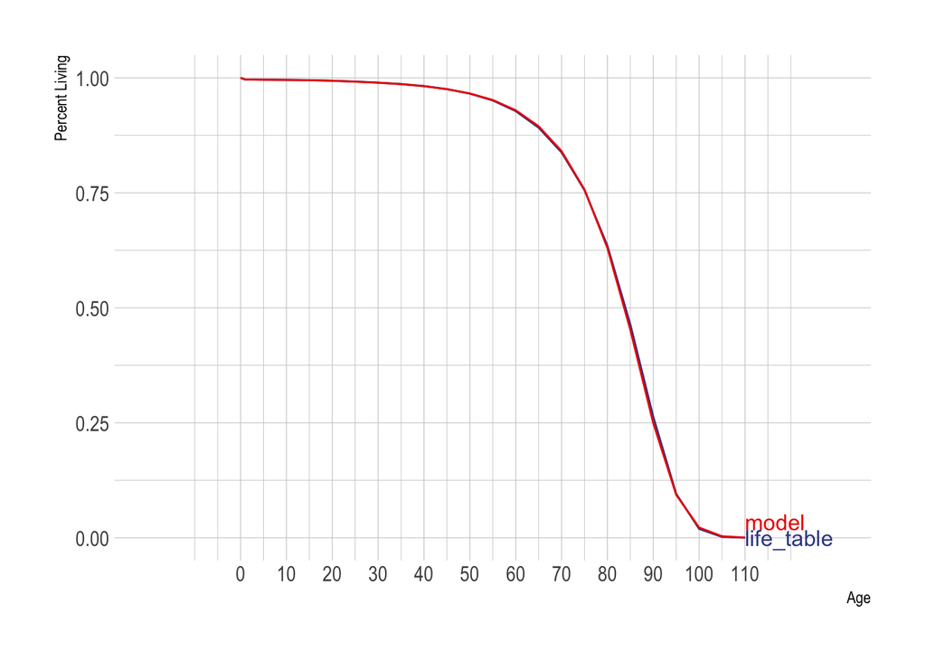

Survival Curve

```r
# Check Life Expectancy vs. Life Table
lt_ <- df_life_table %>%
    select(location_name,location_id,life_table) %>%
    unnest(cols = c(life_table))  %>%
    select(location_name, location_id, age, ex, qx)   %>%
    filter(age >= params1$age0) %>%
    mutate(age_diff = c(1,lead(diff(age)))) %>%
    mutate(mx = -log(1 - qx)/age_diff) %>%
    select(location_name, location_id, age, ex, qx, mx)  %>%
    mutate(p = 1 - qx) %>%
    mutate(cump = ifelse(row_number() == 1, 1, lag(cumprod(p)))) %>%
    mutate(lx = radix * cump) %>%
    mutate(dx = lx * qx) %>%
    as.data.table()

d_ <- c(1,1,0,0)
as.matrix(tr) %*% d_ %>% data.frame() %>%
    as_tibble() %>%
    set_names(c('model')) %>%
    mutate(age = params$ages_trace) %>%
    inner_join(lt_ %>% select(age,life_table = cump)) %>%
    gather(method,value,-age)  %>%
    ggplot(aes(x = age, y = value)) + geom_line(aes(colour=method)) +
    theme_ipsum() +
    geom_dl(method = list("last.points","bumpup"), aes(label = method, colour = method)) +
    scale_x_continuous(expand = c(.25,0), breaks = seq(0,110,10)) +
    theme(legend.position="none") +
    scale_colour_aaas() +
    labs(x = "Age", y = "Percent Living")
```

## Checkpoint: CVD Prevalence

**Prevalence by Age, Model vs. GBD Data**

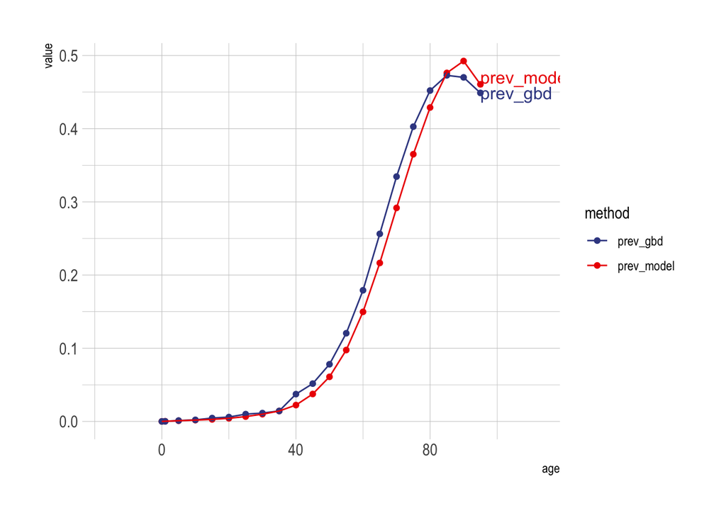

```r
df_prevalence <-
  tibble::tribble(
      ~measure_id, ~measure_name, ~location_id,   ~location_name, ~sex_id, ~sex_name, ~age_id,     ~age_name, ~cause_id,               ~cause_name, ~metric_id, ~metric_name, ~year,        ~val,      ~upper,      ~lower,
               5L,  "Prevalence",          95L, "United Kingdom",      3L,    "Both",      5L,   "1-4 years",      491L, "Cardiovascular diseases",         2L,    "Percent", 2019L,   0.0000878, 0.000129159,   0.0000585,
               5L,  "Prevalence",          95L, "United Kingdom",      3L,    "Both",      6L,   "5-9 years",      491L, "Cardiovascular diseases",         2L,    "Percent", 2019L, 0.001149058, 0.001697486, 0.000762774,
               5L,  "Prevalence",          95L, "United Kingdom",      3L,    "Both",      7L, "10-14 years",      491L, "Cardiovascular diseases",         2L,    "Percent", 2019L, 0.002124186, 0.003148646, 0.001371886,
               5L,  "Prevalence",          95L, "United Kingdom",      3L,    "Both",      8L, "15-19 years",      491L, "Cardiovascular diseases",         2L,    "Percent", 2019L, 0.004583822, 0.006644945, 0.003073985,
               5L,  "Prevalence",          95L, "United Kingdom",      3L,    "Both",      9L, "20-24 years",      491L, "Cardiovascular diseases",         2L,    "Percent", 2019L, 0.005942458, 0.008226115, 0.004300527,
               5L,  "Prevalence",          95L, "United Kingdom",      3L,    "Both",     10L, "25-29 years",      491L, "Cardiovascular diseases",         2L,    "Percent", 2019L,  0.00996704, 0.013682815, 0.007414362,
               5L,  "Prevalence",          95L, "United Kingdom",      3L,    "Both",     11L, "30-34 years",      491L, "Cardiovascular diseases",         2L,    "Percent", 2019L, 0.011397874, 0.014942621, 0.009118873,
               5L,  "Prevalence",          95L, "United Kingdom",      3L,    "Both",     12L, "35-39 years",      491L, "Cardiovascular diseases",         2L,    "Percent", 2019L, 0.014296479, 0.016443542,  0.01252059,
               5L,  "Prevalence",          95L, "United Kingdom",      3L,    "Both",     13L, "40-44 years",      491L, "Cardiovascular diseases",         2L,    "Percent", 2019L, 0.037308496, 0.045780893, 0.031435951,
               5L,  "Prevalence",          95L, "United Kingdom",      3L,    "Both",     14L, "45-49 years",      491L, "Cardiovascular diseases",         2L,    "Percent", 2019L, 0.051644521, 0.057469379, 0.046823625,
               5L,  "Prevalence",          95L, "United Kingdom",      3L,    "Both",     15L, "50-54 years",      491L, "Cardiovascular diseases",         2L,    "Percent", 2019L, 0.078084533, 0.086939447, 0.070462836,
               5L,  "Prevalence",          95L, "United Kingdom",      3L,    "Both",     16L, "55-59 years",      491L, "Cardiovascular diseases",         2L,    "Percent", 2019L, 0.120485163, 0.132099872, 0.109649198,
               5L,  "Prevalence",          95L, "United Kingdom",      3L,    "Both",     17L, "60-64 years",      491L, "Cardiovascular diseases",         2L,    "Percent", 2019L,  0.17921163,  0.19685285,  0.16262344,
               5L,  "Prevalence",          95L, "United Kingdom",      3L,    "Both",     18L, "65-69 years",      491L, "Cardiovascular diseases",         2L,    "Percent", 2019L, 0.256318787, 0.277513117, 0.236628128,
               5L,  "Prevalence",          95L, "United Kingdom",      3L,    "Both",     19L, "70-74 years",      491L, "Cardiovascular diseases",         2L,    "Percent", 2019L, 0.334571503, 0.360158788, 0.307798254,
               5L,  "Prevalence",          95L, "United Kingdom",      3L,    "Both",     20L, "75-79 years",      491L, "Cardiovascular diseases",         2L,    "Percent", 2019L, 0.402821035, 0.432475543, 0.373508479,
               5L,  "Prevalence",          95L, "United Kingdom",      3L,    "Both",     28L,     "<1 year",      491L, "Cardiovascular diseases",         2L,    "Percent", 2019L, 0.000000668,  0.00000144, 0.000000237,
               5L,  "Prevalence",          95L, "United Kingdom",      3L,    "Both",     30L,       "80-84",      491L, "Cardiovascular diseases",         2L,    "Percent", 2019L, 0.452174474, 0.483670261, 0.419854319,
               5L,  "Prevalence",          95L, "United Kingdom",      3L,    "Both",     31L,       "85-89",      491L, "Cardiovascular diseases",         2L,    "Percent", 2019L, 0.472928576, 0.506979294, 0.441347641,
               5L,  "Prevalence",          95L, "United Kingdom",      3L,    "Both",     32L,       "90-94",      491L, "Cardiovascular diseases",         2L,    "Percent", 2019L, 0.470160144, 0.508229264, 0.437316163,
               5L,  "Prevalence",          95L, "United Kingdom",      3L,    "Both",    235L,   "95+ years",      491L, "Cardiovascular diseases",         2L,    "Percent", 2019L, 0.448909821, 0.488972286, 0.413508609
      ) %>%
  inner_join(lut_age_incidence,"age_name") %>%
  select(age,val)

as.matrix(tr) %>%
  as_tibble() %>%
  mutate(age = params$ages_trace) %>%
  filter(age %in% lut_age_incidence$age)  %>%
  mutate(prev_model = CVD / (CVD + Healthy)) %>%
  select(age,prev_model) %>%
  data.frame() %>%
  left_join(df_prevalence %>% rename(prev_gbd = val),"age") %>%
  gather(method,value,-age) %>%
  ggplot(aes(x = age, y = value, colour = method)) + geom_point() +  geom_line() +
  geom_dl(method=list("last.points","bumpup"),aes(label = method)) +
  theme_ipsum() +
  scale_colour_aaas() +
  scale_x_comma(expand = c(0.25,0))
```

**Calculate Outcomes**

```r
# Life Expectancy (Non-Discounted)
le_ = with(params1,(matrix(c(1,
              1 ,
              0,
              0),
            dimnames = list(c(
                c(tr_names,ab_names)
            ), c("DW")))
))

LEt <- trace1 %>% map( ~ ({
    tmp = as.matrix(.x) %*% le_
    tmp
}))

LE = LEt %>% map(~sum(.x * gen_wcc(params1$omega, method = params1$cycle_correction)))


# Life Expectancy (Non-Discounted)
qaly_ = with(params1,(matrix(c(uH,
              uCVD ,
              0,
              0),
            dimnames = list(c(
                c(tr_names,ab_names)
            ), c("DW")))
))

QALYt <- trace1 %>% map( ~ ({
    tmp = as.matrix(.x) %*% qaly_
    tmp
}))

QALY = QALYt %>% map(~sum(.x * disc * gen_wcc(params1$omega, method = params1$cycle_correction)))

# YLD

yld_ = with(params1,(matrix(c(0,
              dw * Delta_t * (1/r_Delta_t) * (1 - exp(-r_Delta_t)) ,
              0,
              0),
            dimnames = list(c(
                c(tr_names,ab_names)
            ), c("DW")))
))


YLDt <- trace1 %>% map( ~ ({
    tmp = as.matrix(.x) %*% yld_
    tmp
}))

YLD = YLDt %>% map(~sum(.x*  disc * gen_wcc(params1$omega, method = params1$cycle_correction)))

# YLL

new_deaths_from_disease <-
    map(trace1,~({
        c(0,diff(.x[,"DeathCVD"]))
    }))

remaining_life_expectancy <-
    with(params1,(1/r_ann) * (1 - exp(-r_ann * fExR(ages_trace))))

YLLt <-
    new_deaths_from_disease %>% map(~(.x * remaining_life_expectancy ))

YLL <-
    YLLt %>% map(~(sum(.x * disc * gen_wcc(params1$omega,method = params1$cycle_correction))))

DALY <-
    map2(YLL,YLD,~(.x + .y))

# QALY-LIKE DALY
qaly_daly_ = with(params1,(matrix(c(0,
               (dw * Delta_t * (1/r_Delta_t) * (1 - exp(-r_Delta_t))) ,
              0,
              1),
            dimnames = list(c(
                c(tr_names,ab_names)
            ), c("DW")))
))


QALY_DALYt <- trace1 %>% map( ~ ({
    tmp = as.matrix(.x) %*% qaly_daly_
    tmp
}))

QALY_DALY = QALY_DALYt %>% map(~sum(.x*  disc * gen_wcc(params1$omega, method = params1$cycle_correction)))

result1 <- cbind(LE, YLD, YLL, DALY, QALY_DALY) %>%
  as.data.frame() %>%
  mutate_all( ~ as.numeric(.))  %>%
  rownames_to_column(var = "strategy") %>%
  mutate(approach = "Markov Trace") %>%
  mutate(LE_LT = lt %>% filter(age == params1$age0) %>% pull(ex)) %>%
  mutate(LE_LT = ifelse(strategy != "natural_history", NA, LE_LT)) %>%
  dplyr::select(approach, strategy, LE_LT, LE, YLD, YLL, DALY, QALY_DALY)

result1 %>%
    kable(digits = 3, col.names = c("Approach","Scenario","Life Expectancy (Life Table)","Life Expectancy (Model)","YLDs","YLLs","DALYs","QALY-like DALY")) %>%
    kable_styling()
```

| Approach | Scenario | Life Expectancy (Life Table) | Life Expectancy (Model) | YLDs | YLLs | DALYs | QALY-like DALY |
| --- | --- | --- | --- | --- | --- | --- | --- |
| Markov Trace | natural_history | 81.07 | 81.081 | 0.363 | 1.921 | 2.284 | 6.772 |
| Markov Trace | prevent |  | 81.188 | 0.334 | 1.787 | 2.121 | 6.314 |
| Markov Trace | treat |  | 81.255 | 0.370 | 1.704 | 2.074 | 6.102 |
| Markov Trace | prevent_treat |  | 81.350 | 0.341 | 1.585 | 1.926 | 5.689 |

# Approach 2: Transition States

**Parameterize Transition State Model**

```r
params2 <- with(params,modifyList(params,list(
    tr_names = c("Healthy","CVD"), # transient health states
    ab_names = c("Death","trDeathCVD"), # absorbing health states
    n_states = 4
)))

params2 <- with(params2,modifyList(params2,list(
    # Natural History Transition Rate Matrix
    mR =
      ages %>% map(~({

        mR_nh =
          matrix(c(
          -(rH_CVD(.x) + rD(.x)), rH_CVD(.x), rD(.x), 0 ,
          0, -(rD(.x)+ rCVD_D(.x)), rD(.x) + rCVD_D(.x),rCVD_D(.x),
          0,0,0,0,
          0,0,0,0),
          nrow = 4,
          ncol = 4,
          byrow=TRUE,
          dimnames = list(c(tr_names,ab_names),
                          c(tr_names,ab_names)
          ))

        mR_prevent =
          matrix(c(
          -(hr_prevent * rH_CVD(.x) + rD(.x)), hr_prevent * rH_CVD(.x), rD(.x), 0 ,
          0, -(rD(.x)+ rCVD_D(.x)), rD(.x) + rCVD_D(.x),rCVD_D(.x),
          0,0,0,0,
          0,0,0,0),
          nrow = 4,
          ncol = 4,
          byrow=TRUE,
          dimnames = list(c(tr_names,ab_names),
                          c(tr_names,ab_names)
          ))

        mR_treat =
          matrix(c(
          -(rH_CVD(.x) + rD(.x)), rH_CVD(.x), rD(.x), 0 ,
          0, -(rD(.x)+ hr_treat * rCVD_D(.x)), rD(.x) + hr_treat * rCVD_D(.x),hr_treat * rCVD_D(.x),
          0,0,0,0,
          0,0,0,0),
          nrow = 4,
          ncol = 4,
          byrow=TRUE,
          dimnames = list(c(tr_names,ab_names),
                          c(tr_names,ab_names)
          ))

        mR_prevent_treat =
          matrix(c(
          -(hr_prevent * rH_CVD(.x) + rD(.x)), hr_prevent * rH_CVD(.x), rD(.x), 0 ,
          0, -(rD(.x)+ hr_treat * rCVD_D(.x)), rD(.x) + hr_treat * rCVD_D(.x),hr_treat * rCVD_D(.x),
          0,0,0,0,
          0,0,0,0),
          nrow = 4,
          ncol = 4,
          byrow=TRUE,
          dimnames = list(c(tr_names,ab_names),
                          c(tr_names,ab_names)
          ))
        array(c(as.vector(mR_nh),as.vector(mR_prevent), as.vector(mR_treat),as.vector(mR_prevent_treat)), dim = c(length(tr_names)+ length(ab_names),length(tr_names)+ length(ab_names),length(tx_names)),
          dimnames = list(c(tr_names,ab_names),c(tr_names,ab_names),tx_names)) %>%
            apply(.,3,function(x) x, simplify=FALSE)
      }))
)))

params2 <- with(params2,modifyList(params2,list(
    mP = mR %>% transpose() %>% map(~({
      mR_ = .x
      mR_ %>% map(~({
              tmp = expm(.x * Delta_t)
              tmp["trDeathCVD","trDeathCVD"] = 0
              tmp
         }))
      }))
)))
```

**Construct Markov Trace**

```r
trace2 <-
    with(params2, {
        mP %>% map( ~ ({
            P = .x
            occ <- s0T
            P %>% map(~({
              occ <<- occ %*% .x
            })) %>%
            map(~(data.frame(.x))) %>%
            bind_rows()
        }))
    }) %>%
    map(~({
        tmp = .x[1,]
        tmp[1,] = params$s0T
        tmp = rbind(tmp,.x)
    }))
```

**Calculate Outcomes Based on Death Transitions**

```r
# Life Expectancy (Non-Discounted)
le_ = with(params2,(matrix(c(1,
              1 ,
              0,
              0),
            dimnames = list(c(
                c(tr_names,ab_names)
            ), c("DW")))
))

LEt <- trace2 %>% map( ~ ({
    tmp = as.matrix(.x) %*% le_
    tmp
}))

LE2 = LEt %>% map(~sum(.x * gen_wcc(params1$omega, method = params1$cycle_correction)))

# Life Expectancy (Non-Discounted)
qaly_ = with(params2,(matrix(c(uH,
              uCVD ,
              0,
              0),
            dimnames = list(c(
                c(tr_names,ab_names)
            ), c("DW")))
))

QALYt <- trace2 %>% map( ~ ({
    tmp = as.matrix(.x) %*% qaly_
    tmp
}))

QALY2 = QALYt %>% map(~sum(.x * disc * gen_wcc(params1$omega, method = params1$cycle_correction)))

# YLD

yld_ = with(params2,(matrix(c(0,
              dw * Delta_t * (1/r_Delta_t) * (1 - exp(-r_Delta_t)) ,
              0,
              0),
            dimnames = list(c(
                c(tr_names,ab_names)
            ), c("DW")))
))


YLDt <- trace2 %>% map( ~ ({
    tmp = as.matrix(.x) %*% yld_
    tmp
}))

YLD2 = YLDt %>% map(~sum(.x*  disc * gen_wcc(params1$omega, method = params1$cycle_correction)))

# YLL
Ex <- matrix(0,ncol= 4, nrow = params2$omega+1)
Ex[,4] =  with(params1,(1/r_ann) * (1 - exp(-r_ann * fExR(ages_trace))))

YLLt <-
    trace2 %>% map(~({
      .x * Ex
    }))

YLL2 <-
    YLLt %>% map(~(sum(.x * disc * gen_wcc(params1$omega,method = params1$cycle_correction))))

DALY2 <-
    map2(YLL2,YLD,~(.x + .y))

# QALY-LIKE DALY
qaly_daly_ = with(params1,(matrix(c(0,
               (dw * Delta_t * (1/r_Delta_t) * (1 - exp(-r_Delta_t))) ,
              0,
              1),
            dimnames = list(c(
                c(tr_names,ab_names)
            ), c("DW")))
))


QALY_DALYt2 <- trace1 %>% map( ~ ({
    tmp = as.matrix(.x) %*% qaly_daly_
    tmp
}))

QALY_DALY2 = QALY_DALYt2 %>% map(~sum(.x*  disc * gen_wcc(params1$omega, method = params1$cycle_correction)))


result2 <- cbind(LE2, YLD2,YLL2,DALY2,QALY_DALY2) %>%
    as.data.frame() %>%
    mutate_all(~as.numeric(.))  %>%
    rownames_to_column(var="strategy") %>%
    mutate(approach = "Transition States") %>%
    dplyr::select(approach, strategy, LE = LE2, YLD=YLD2, YLL=YLL2, DALY=DALY2,QALY_DALY=QALY_DALY2)

tib <- result1 %>%
    bind_rows(result2)

tib %>%
    arrange(strategy) %>%
    select(-strategy) %>%
    kable(digits = 3, col.names = c("Approach","Life Expectancy (Life Table)","Life Expectancy (Model)","YLDs","YLLs","DALYs","DALY-like QALY")) %>%
    kable_styling() %>%
    pack_rows(index = c("natural_history" = 2, "prevention" = 2, "treatment" = 2,"prevent_treat" = 2)) %>%
    kable_styling()
```

[output not shown]

# Approach 3: Markov Chain with Rewards

**Parameterize the Healthy Longevity Model (continued)**

```r
vec <-  # a simple function to return the vec of an array
    function(x) {
        y <- c(x)
        return(y)
    }

vecperm <-
    # vecperm
    # function to calculate the vec permutation matrix K of index m,n
    # let X be a m x n matrix, and X' the transpose of X
    # then K satisfies
    # vec(X') = K*vec(X)
    function(m, n) {
        K <- matrix(0, m * n, m * n)
        a <- matrix(0, m, n)

        for (i in 1:m) {
            for (j in 1:n) {
                e <- a
                e[i, j] <- 1
                K <- K + kronecker(e, t(e))
            }
        }

        return(K)
    }

params3_ <- with(params,modifyList(params,list(
    alpha = length(ab_names),
    tau = length(tr_names),
    s = length(tr_names)*omega + length(ab_names), #total number of states;s=τω+α
    # Age transition Matrix
    D = {
        # Create diagonal age advancement matrix
        D <- matrix(0, omega, omega)
        vec <- rep(1, omega-1)
        D[row(D)-1 == col(D)] <- vec
        D[omega,omega] = 1
        D
    }
)))

params3_ <- with(params3_,modifyList(params3_,list(
    # Natural History Transition Rate Matrix
    mR =
      ages %>% map(~({
        mR_nh =
          matrix(c(
          -(rH_CVD(.x) + rD(.x)), rH_CVD(.x), rD(.x), 0 ,
          0, -(rD(.x)+ rCVD_D(.x)), rD(.x),rCVD_D(.x),
          0,0,0,0,
          0,0,0,0),
          nrow = 4,
          ncol = 4,
          byrow=TRUE,
          dimnames = list(c(tr_names,ab_names),
                          c(tr_names,ab_names)
          ))

        mR_prevent =
          matrix(c(
          -(hr_prevent * rH_CVD(.x) + rD(.x)), hr_prevent * rH_CVD(.x), rD(.x), 0 ,
          0, -(rD(.x)+ rCVD_D(.x)), rD(.x),rCVD_D(.x),
          0,0,0,0,
          0,0,0,0),
          nrow = 4,
          ncol = 4,
          byrow=TRUE,
          dimnames = list(c(tr_names,ab_names),
                          c(tr_names,ab_names)
          ))

        mR_treat =
          matrix(c(
          -(rH_CVD(.x) + rD(.x)), rH_CVD(.x), rD(.x), 0 ,
          0, -(rD(.x)+ hr_treat * rCVD_D(.x)), rD(.x),hr_treat * rCVD_D(.x),
          0,0,0,0,
          0,0,0,0),
          nrow = 4,
          ncol = 4,
          byrow=TRUE,
          dimnames = list(c(tr_names,ab_names),
                          c(tr_names,ab_names)
          ))

        mR_prevent_treat =
          matrix(c(
          -(hr_prevent * rH_CVD(.x) + rD(.x)), hr_prevent * rH_CVD(.x), rD(.x), 0 ,
          0, -(rD(.x)+ hr_treat * rCVD_D(.x)), rD(.x),hr_treat * rCVD_D(.x),
          0,0,0,0,
          0,0,0,0),
          nrow = 4,
          ncol = 4,
          byrow=TRUE,
          dimnames = list(c(tr_names,ab_names),
                          c(tr_names,ab_names)
          ))
        array(c(as.vector(mR_nh),as.vector(mR_prevent), as.vector(mR_treat),as.vector(mR_prevent_treat)), dim = c(length(tr_names)+ length(ab_names),length(tr_names)+ length(ab_names),length(tx_names)),
          dimnames = list(c(tr_names,ab_names),c(tr_names,ab_names),tx_names)) %>%
            apply(.,3,function(x) t(x), simplify=FALSE)
      }))
)))

# not sure why this is needed, but otherwise the length ogets set too long...
params3 <- with(params3_, modifyList(params3_, list(mR_ = mR %>% transpose())))
params3$mR = params3$mR_

params3 <- with(params3,modifyList(params3,list(
    mV = mR %>% map(~({
            R = .x
            R %>% map(~({
              m <- .x[tr_names,tr_names]
            }))

        })),

    mQ = mR %>% map(~({
      R = .x
      R %>% map(~({
                V = .x[tr_names,tr_names]
                S = .x[ab_names,tr_names]
                zero_ <- matrix(0, nrow = length(tr_names)+length(ab_names), ncol = length(ab_names))
                tmp <- cbind(rbind(V,S),zero_)
                dimnames(tmp) <- list(c(tr_names,ab_names),c(tr_names,ab_names))
                tmp
      }))
    }))
)))

params3 <- with(params3,modifyList(params3,list(
    mP = mQ %>% map(~({
          Q = .x
          Q %>% map(~(expm(.x * Delta_t)))
    }))
)))

params3 <- with(params3,modifyList(params3,list(
    mU = mP %>% map(~({
          P <- .x
          P %>% map(~(.x[tr_names,tr_names]))
    })),
    mM = mP %>% map(~({
        P = .x
        P %>% map(~(.x[ab_names,tr_names]))

    })),
    bbD_ = kronecker(diag(tau), D)
)))

params3 <- with(params3,modifyList(params3,list(
    bbU_ =  mU %>%
            map(~(bdiag(.x))),
    K = vecperm(tau, omega)
)))

params3 <- with(params3,modifyList(params3,list(
    mUtilde = bbU_ %>% map( ~ ({
        t(K) %*% bbD_ %*% K %*% .x
    }))
)))

params3 <- with(params3,modifyList(params3,list(
    mMtilde = mM %>% map(~({
      do.call(cbind,.x)
    }))
)))

params3 <- with(params3,modifyList(params3,list(
    mPtilde =  map2(mUtilde, mMtilde,  ~ ({
            rbind(cbind(.x, matrix(0, tau * omega, alpha)) ,
                  cbind(.y, diag(alpha)))
        }))
)))
```

**Calculate DALY Outcomes**

```r
healthy_longevity_occupancy <- function(params, H, V) {
    with(params,{
        map2(mUtilde,mPtilde,~({
            U = .x
            P = .y
            N = solve(diag(tau*omega)-U)
            h = vec(H) %>% as.matrix()
            not_h = 1-h
            v <- vec(V) %>% as.matrix()
            B1 <- h %*% t(v) + 0.5 * (not_h %*% t(v)) + 0.5 * (v %*% t(not_h)) # Eq. 46
            C1 = 0.5 * (rep(1,alpha) %*%  t(v)) # Eq. 48
            R1 = rbind(cbind(B1, matrix(0, tau * omega, alpha)) ,
                              cbind(C1, diag(alpha)))
            R2 = R1 * R1
            R3 = R1 * R1 * R1
            Z = cbind(diag(tau*omega),matrix(0,nrow=tau*omega, ncol=alpha))
            e = rep(1,s)
            rho1_ <- t(N)%*% Z %*% t(P * R1) %*% e
            # The following needs to be debugged
            # rho2_ <-
            #   N %*% (Z %*% t(.y * R1) %*% e + 2 * t(.x * B1) %*% rho1_)
            # B2 <- R2[1:(tau * omega), 1:(tau * omega)]
            # rho3_ <- t(N) %*% (Z %*% ((t(.y * R3) %*% e)) + 3 * (t(.x * B2) %*% rho1_) + 3 * (t(.x * B1) %*% rho2_))
            rho1_
        }))
    })
}

healthy_longevity_yll <- function(params, life_expectancy, disc) {
    with(params,{
        map2(mUtilde,mPtilde,~({
            U = .x
            P = .y
            N = solve(diag(tau*omega)-U)
            Z = cbind(diag(tau*omega),matrix(0,nrow=tau*omega, ncol=alpha))
            disc_ = rev(sort(rep(disc,length(tr_names))))
            eta1_ex_ = rev(sort(rep(life_expectancy,length(tr_names))))
            eta1_ex =  eta1_ex_

            B1 = matrix(0,nrow=tau*omega, ncol = tau*omega)
            C1 = rbind(matrix(0,nrow=1,ncol=tau*omega),eta1_ex*disc_)
            R1 = cbind(rbind(B1,C1),matrix(0,nrow=tau*omega+2,ncol=2))
            R2 = R1 * R1
            R3 = R1 * R1 * R1
            Z = cbind(diag(tau*omega),matrix(0,nrow=tau*omega, ncol=alpha))
            e = rep(1,s)
            rho1_ = t(N) %*% Z %*% t(.y * R1) %*% e
            # The following needs to be debugged
            # rho2_ <-
            #   N %*% (Z %*% t(.y * R1) %*% e + 2 * t(.x * B1) %*% rho1_)
            # B2 <- R2[1:(tau * omega), 1:(tau * omega)]
            # rho3_ <- t(N) %*% (Z %*% ((t(.y * R3) %*% e)) + 3 * (t(.x * B2) %*% rho1_) + 3 * (t(.x * B1) %*% rho2_))
            rho1_
        }))
    })
}

# Life Expectancy

H = with(params3,matrix(1,nrow=tau, ncol=omega))
V_LE = with(params3,matrix(1,nrow=tau, ncol = omega))
# Only include the below if discounting remaining life expectancy
# V_LE[1,] <- disc
# V_LE[2,] <- disc
# V_LE[3,] <- disc

V_YLD = with(params3,matrix(0,nrow=tau, ncol = omega))
V_YLD[2,] <- disc[-length(disc)]*with(params3,dw * Delta_t * (1/r_Delta_t) * (1 - exp(-r_Delta_t)))

V_QALY = with(params3,matrix(0,nrow=tau, ncol = omega))
V_QALY[1,] <- disc[-length(disc)]*with(params3,uH)
V_QALY[2,] <- disc[-length(disc)]*with(params3,uCVD)

LE3_ <- params3 %>% healthy_longevity_occupancy(H = H, V = V_LE)
QALY3_ <- params3 %>% healthy_longevity_occupancy(H = H, V = V_QALY)
YLD3_ <- params3 %>% healthy_longevity_occupancy(H = H, V = V_YLD)

remaining_life_expectancy <- with(params3,(1/r_ann) * (1 - exp(-r_ann * fExR(ages))))
YLL3_ <- params3 %>% healthy_longevity_yll(life_expectancy = remaining_life_expectancy, disc = disc[-length(disc)])
DALY3_ <- map2(YLL3_,YLD3_,~(.x+.y))

qaly_daly_ <- rep(1,length(params3$ages))
QALY_DALY3_YLL_ <- params3 %>% healthy_longevity_occupancy(H = H, V = V_LE)
QALY_DALY3_ <- map2(QALY_DALY3_YLL_,YLD3_,~(.x+.y))

LE3 <- LE3_ %>% map(~({
  tmp <- (kronecker(t(c(1,rep(0,params3$omega-1))) ,diag(params3$tau)) %*% as.matrix(.x))
  tmp[1,1]
}))

QALY3 <- QALY3_ %>% map(~({
  tmp <- (kronecker(t(c(1,rep(0,params3$omega-1))) ,diag(params3$tau)) %*% as.matrix(.x))
  tmp[1,1]
}))

YLD3 <- YLD3_ %>% map(~({
  tmp <- (kronecker(t(c(1,rep(0,params3$omega-1))) ,diag(params3$tau)) %*% as.matrix(.x))
  tmp[1,1]
}))

YLL3 <- YLL3_ %>% map(~({
  tmp <- (kronecker(t(c(1,rep(0,params3$omega-1))) ,diag(params3$tau)) %*% as.matrix(.x))
  tmp[1,1]
}))

DALY3 <- DALY3_ %>% map(~({
  tmp <- (kronecker(t(c(1,rep(0,params3$omega-1))) ,diag(params3$tau)) %*% as.matrix(.x))
  tmp[1,1]
}))

QALY_DALY3 <- QALY_DALY3_ %>% map(~({
  tmp <- (kronecker(t(c(1,rep(0,params3$omega-1))) ,diag(params3$tau)) %*% as.matrix(.x))
  tmp[1,1]
}))


QALY_DALY3 = QALY3 %>% map(~(NA))

result3 <- cbind(LE3, YLD3,YLL3,DALY3,QALY_DALY3) %>%
    as.data.frame() %>%
    mutate_all(~as.numeric(.))  %>%
    rownames_to_column(var="strategy") %>%
    mutate(approach = "Markov Chain With Rewards") %>%
    dplyr::select(approach, strategy, LE = LE3, YLD=YLD3, YLL=YLL3, DALY=DALY3,QALY_DALY=QALY_DALY3)

tib <- result1 %>%
    bind_rows(result2) %>%
  bind_rows(result3)

tib %>%
    arrange(strategy) %>%
    select(-strategy) %>%
    kable(digits = 3, col.names = c("Approach","Life Expectancy (Life Table)","Life Expectancy (Model)","YLDs","YLLs","DALYs","DALY-like QALY")) %>%
    kable_styling() %>%
    pack_rows(index = c("natural_history" =3, "prevention" = 3, "treatment" = 3,"prevent_treat" = 3)) %>%
    kable_styling()
```

[output not shown]

**DALY changes**

```r
tib %>%
    gather(outcome,value,-approach,-strategy) %>%
    na.omit() %>%
    unite(outcome,outcome,strategy) %>%
    spread(outcome,value) %>%
    select(approach,starts_with("DALY")) %>%
    mutate(DALY_prevent = DALY_prevent - DALY_natural_history,
           DALY_treat = DALY_treat - DALY_natural_history,
           DALY_prevent_treat = DALY_prevent_treat - DALY_natural_history) %>%
    select(approach, DALY_natural_history, DALY_prevent, DALY_treat, DALY_prevent_treat) %>%
    mutate(approach = factor(approach,levels = c("Markov Trace","Transition States","Markov Chain With Rewards"))) %>%
    arrange(approach) %>%
    kable(digits = 3, col.names = c("Approach","DALY (ref.)", "incDALY Prevention","incDALY Treatment","incDALY Prevention and Treatment")) %>%
    kable_styling()
```

Disability-Adjusted Life Year Outcome Changes Relative to Natural History Model

| Approach | DALY (ref.) | incDALY Prevention | incDALY Treatment | incDALY Prevention and Treatment |
| --- | --- | --- | --- | --- |
| Markov Trace | 2.284 | -0.163 | -0.210 | -0.358 |
| Transition States | 2.284 | -0.163 | -0.210 | -0.358 |
| Markov Chain With Rewards | 2.376 | -0.169 | -0.221 | -0.375 |

**DALY changes, contd**

```r
tib %>%
    gather(outcome,value,-approach,-strategy) %>%
    na.omit() %>%
    unite(outcome,outcome,strategy) %>%
    spread(outcome,value) %>%
    select(approach,starts_with("QALY_DALY")) %>%
    mutate(QALY_DALY_prevent = QALY_DALY_prevent - QALY_DALY_natural_history,
           QALY_DALY_treat = QALY_DALY_treat - QALY_DALY_natural_history,
           QALY_DALY_prevent_treat = QALY_DALY_prevent_treat - QALY_DALY_natural_history) %>%
    select(approach, QALY_DALY_natural_history, QALY_DALY_prevent, QALY_DALY_treat, QALY_DALY_prevent_treat) %>%
    mutate(approach = factor(approach,levels = c("Markov Trace","Transition States","Healthy Longevity"))) %>%
    arrange(approach) %>%
    kable(digits = 3, col.names = c("Approach","DALY (ref.)", "incDALY Prevention","incDALY Treatment","incDALY Prevention and Treatment")) %>%
    kable_styling()
```

Disability-Adjusted Life Year Outcome Changes Relative to Natural History Model

| Approach | DALY (ref.) | incDALY Prevention | incDALY Treatment | incDALY Prevention and Treatment |
| --- | --- | --- | --- | --- |
| Markov Trace | 6.772 | -0.458 | -0.67 | -1.083 |
| Transition States | 6.772 | -0.458 | -0.67 | -1.083 |

**QALY plot**

```r
tibble(approach = rep("Markov Trace",4), strategy=names(unlist(QALY)),  QALY = unlist(QALY)) %>%
  bind_rows(
    tibble(approach = rep("Transition States",4), strategy=names(unlist(QALY2)),  QALY = unlist(QALY2))
  ) %>%
  bind_rows(
    tibble(approach = rep("Healthy Longevity",4), strategy = names(unlist(QALY2)), QALY = c(QALY3$natural_history[1],QALY3$prevent[1],QALY3$treat[1],QALY3$prevent_treat[1]))
  ) %>%
  mutate(outcome = glue("QALY_{strategy}")) %>%
  rename(value = QALY) %>%
  select(approach,outcome,value) %>%
  spread(outcome,value) %>%
  mutate(  QALY_prevent = QALY_prevent - QALY_natural_history,
           QALY_treat = QALY_treat - QALY_natural_history,
           QALY_prevent_treat = QALY_prevent_treat - QALY_natural_history) %>%
    select(approach, QALY_natural_history, QALY_prevent, QALY_treat, QALY_prevent_treat) %>%
    mutate(approach = factor(approach,levels = c("Markov Trace","Transition States","Healthy Longevity"))) %>%
    arrange(approach) %>%
    kable(digits = 3, col.names = c("Approach","QALY (ref.)", "incQALY Prevention","incQALY Treatment","incQALY Prevention and Treatment")) %>%
    kable_styling()
```

Quality Adjusted Life Year Outcome Changes Relative to Natural History Model

| Approach | QALY (ref.) | incQALY Prevention | incQALY Treatment | incQALY Prevention and Treatment |
| --- | --- | --- | --- | --- |
| Markov Trace | 79.066 | 0.268 | 0.135 | 0.393 |
| Transition States | 79.066 | 0.268 | 0.135 | 0.393 |
| Healthy Longevity | 79.122 | 0.264 | 0.135 | 0.389 |

## DALys Based on Endogenous Life Expectancy

$$\tilde{\eta}_1^T = 1^T_{\tau_\omega} \tilde{N}$$

**DALYs based on endogenous life expectancy**

```r
N = with(params3,({
  mUtilde %>% map(~({
    solve(diag(tau*omega)-.x)
  }))
}))

remaining_life_expectancy_endogenous = as.vector(t(rep(1,params3$tau*params3$omega)) %*% N[[1]]) %>% {.[seq(1,params3$tau*params3$omega,2)]}
YLL3_endogenous <- params3 %>% healthy_longevity_yll(life_expectancy = remaining_life_expectancy_endogenous, disc = disc[-length(disc)])

remaining_life_expectancy_endogenous <- LE3 %>% map(~({.x[seq(1,params3$tau*params3$omega,2)]})) %>% {.$natural_history}
YLL3_endogenous <- params3 %>% healthy_longevity_yll(life_expectancy = remaining_life_expectancy_endogenous, disc = disc[-length(disc)])
```

## DALYs by Year

**Create Plot by Age**

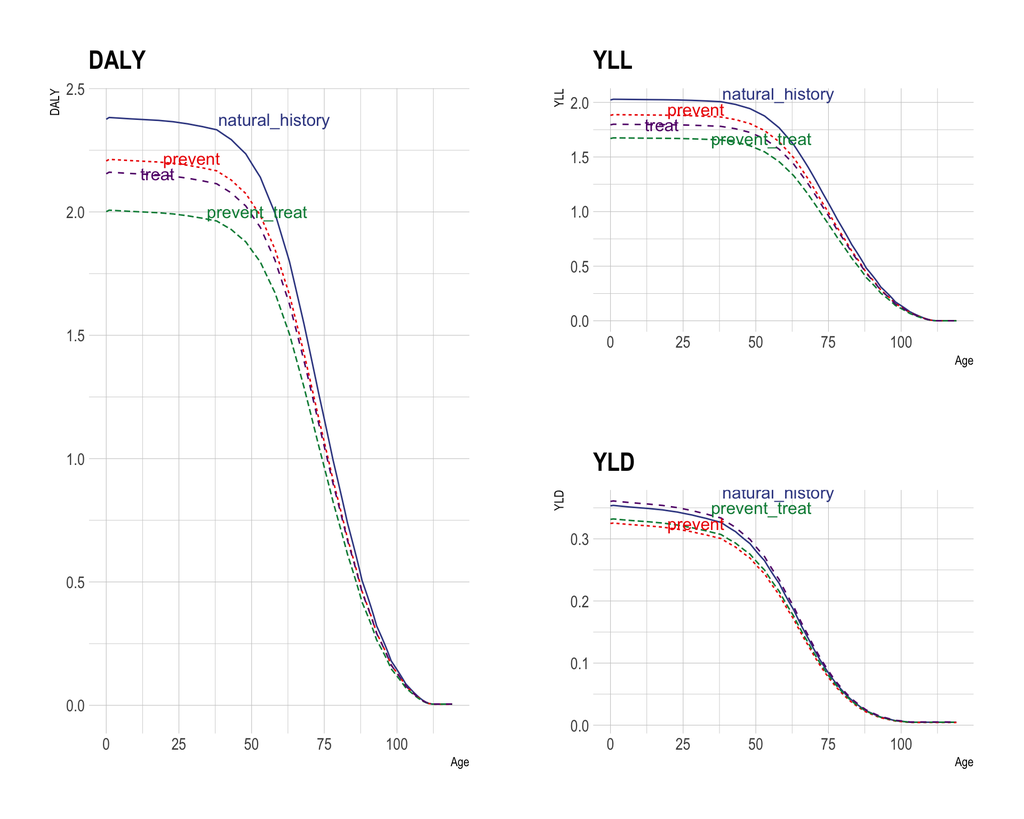

DALYs by Model Starting Age

```r
p1 = YLL3_ %>% map(~({
  as.data.frame(kronecker(diag(params3$omega),t(c(1,0))) %*% as.matrix(.x)) %>%
  mutate(age = params3$ages)  %>%
  mutate(initial = params3$tr_names[1])
})) %>%
  set_names(params3$tx_names) %>%
  bind_rows(.id = "strategy") %>%
  ggplot(aes(x = age, y = V1, colour = strategy, lty=strategy)) + geom_line() + theme_ipsum() +
  scale_colour_aaas() +
  geom_dl(method = list("first.points","bumpup", hjust=-1),aes(label = strategy)) +
    theme(legend.position = "none") + ggtitle("YLL") + labs(x = "Age", y = "YLL")

p2 = YLD3_ %>% map(~({
  as.data.frame(kronecker(diag(params3$omega),t(c(1,0))) %*% as.matrix(.x)) %>%
  mutate(age = params3$ages)  %>%
  mutate(initial = params3$tr_names[1])
})) %>%
  set_names(params3$tx_names) %>%
  bind_rows(.id = "strategy") %>%
  ggplot(aes(x = age, y = V1, colour = strategy, lty=strategy)) + geom_line() + theme_ipsum() +
  scale_colour_aaas() +
  geom_dl(method = list("first.points","bumpup", hjust=-1),aes(label = strategy))  +
  theme(legend.position = "none") + ggtitle("YLD") + labs(x = "Age", y = "YLD")

p3 = DALY3_ %>% map(~({
  as.data.frame(kronecker(diag(params3$omega),t(c(1,0))) %*% as.matrix(.x)) %>%
  mutate(age = params3$ages)  %>%
  mutate(initial = params3$tr_names[1])
})) %>%
  set_names(params3$tx_names) %>%
  bind_rows(.id = "strategy") %>%
  ggplot(aes(x = age, y = V1, colour = strategy, lty=strategy)) + geom_line() + theme_ipsum() +
  scale_colour_aaas() +
  geom_dl(method = list("first.points","bumpup", hjust=-1),aes(label = strategy))  +
  theme(legend.position = "none") + ggtitle("DALY") + labs(x = "Age", y = "DALY")


p3 + p1  / p2
```

## References

Caswell, Hal, and Silke van Daalen. 2021. “Healthy Longevity from Incidence-Based Models: More Kinds of Health Than Stars in the Sky.” *Demographic Research* 45 (July): 397–452. https://doi.org/10.4054/demres.2021.45.13.

Caswell, Hal, and Virginia Zarulli. 2018. “Matrix Methods in Health Demography: A New Approach to the Stochastic Analysis of Healthy Longevity and DALYs.” *Population Health Metrics* 16 (1). https://doi.org/10.1186/s12963-018-0165-5.

Global Burden of Disease Collaborative Network. 2020a. “Global Burden of Disease Study 2019 (GBD 2019) Life Tables 1950-2019.” Institute for Health Metrics; Evaluation (IHME). https://doi.org/10.6069/1PF5-1M37.

———. 2020b. “Global Burden of Disease Study 2019 (GBD 2019) Results.” Seattle, United States: Institute for Health Metrics and Evaluation (IHME).

———. 2021. “Global Burden of Disease Study 2019 (GBD 2019) Reference Life Table.” Institute for Health Metrics; Evaluation (IHME). https://doi.org/10.6069/1D4Y-YQ37.